# Κεφάλαιο 17. Ανάλυση Δικτύων με την R

Χριστόφορος Νικολάου

2023-01-27

## Εισαγωγή

Από την μοριακή και την περιβαλλοντικη βιολογία ως τις τηλεπικοινωνίες και την κοινωνιολογία, όλο και συχνότερα, η μελέτη πολύπλοκων φαινομένων και η συσσώρευση δεδομένων μας οδηγεί σε προσεγγίσεις ανάλυσης δικτύων. Η επιστήμη των δικτύων (Network Science) είναι το ακαδημαϊκό πεδίο που μελετά τις σχέσεις μεταξύ διασυνδεδεμένων οντοτήτων σε διάφορα επίπεδα. Οι οντότητες αυτές αποτελούν τα στοιχεία των δικτύων που ονομάζονται κόμβοι, οι δε σχέσεις μεταξύ τους απεικονίζονται ως ακμές. Τα δίκτυα είναι στην ουσία μαθηματικά αντικείμενα που υπακούν στις αρχές τις θεωρίας των γράφων (graph theory) και μας βοηθούν να περιγράψουμε, να απεικονίσουμε αλλά και να προβλέψουμε πολύπλοκες συμπεριφορές σε πάρα πολλά συστήματα.

Όπως και με πολλά άλλα είδη ανάλυσης δεδομένων, η R προσφέρει τη δυνατότητα όλων των παραπάνω με τη χρήση μιας σειράς συναρτήσεων μέσω -κυρίως- της βιβλιοθήκης $igraph()$. Στο Κεφάλαιο αυτό θα παρουσιάσουμε τις βασικές αρχές της θεωρίας δικτύων στο πλαίσιο εφαρμογών με τη χρήση της R. Πιο συγκεκριμένα, θα δούμε αρχικά πώς μπορούμε να δημιουργήσουμε και να εισαγάγουμε δεδομένα δικτύων στην R. Στη συνέχεια θα παρουσιάσουμε τρόπους για την απεικόνιση δικτύων σε γραφικές παραστάσεις και ακολούθως θα παρουσιάσουμε πιο προχωρημένα στοιχεία της θεωρίας, όπως είναι η μελέτη της τοπολογίας και η στατιστική ανάλυση ιδιοτήτων των δικτύων.

Τέλος θα δούμε συγκεκριμένες εφαρμογές όλων των παραπάνω σε τυπικά δίκτυα προερχόμενα από τις κοινωνικές και τις βιολογικές επιστήμες αλλά και το πεδίο των μεταφορών.

## 17.1 Εισαγωγή στη βιβλιοθήκη igraph

Όπως έχουμε δει σε πάρα πολλές άλλες περιπτώσεις, η R διαθέτει εξειδικευμένες βιβλιοθήκες για μια πλειάδα αναλυτικών προβλημάτων και η περίπτωση των δικτύων δεν αποτελεί εξαίρεση. Η βιβλιοθήκη $igraph()$ (https://igraph.org/) αποτελεί την πιο πλήρη συλλογή συναρτήσεων και αναλυτικών εργαλείων για δίκτυα και προσφέρεται για μια σειρά από συστήματα όπως η C, η Python αλλά και η R. H εγκατάσταση και φόρτωσή της γίνεται κατά τα γνωστά. Παρακάτω θα φορτώσουμε και τη βοηθητική βιβλιοθήκη $igraphdata()$ η οποία θα μας επιτρέψει να χειριστούμε και χαρακτηριστικά σύνολα δεδομένων για τα παραδείγματα που θα παρουσιάσουμε σε αυτό το κεφάλαιο.

```r
library("igraph")
library("igraphdata")
```

## 17.2 Δημιουργία δικτύων στην R

Πρωταρχικό μέλημά μας σε κάθε ανάλυση είναι η κατανόηση και εξοικείωση με τα δεδομένα τα οποία αναλύουμε. Τα αντικείμενα δικτύων που θα αναλύσουμε με τις συναρτήσεις της $igraph()$ έχουν χαρακτηριστική δομή που δεν μοιάζει με ό,τι έχουμε δει ως εδώ κι αυτό συμβαίνει εξαιτίας των σχέσεων που απεικονίζουν. Από τη μία έχουμε στοιχεία-κόμβους και από την άλλη σχέσεις-ακμές που τα συνδέουν. Έτσι, ένα αντικείμενο γράφου/δικτύου (graph) θα πρέπει να περιέχει πληροφορίες και για τις δύο αυτές συνιστώσες, ενώ πολύ συχνά -ειδικά για πολύπλοκα δίκτυα- τα στοιχεία αυτά συνοδεύονται από μια σειρά από περιγραφικές, ποσοτικές ή ποιοτικές μεταβλητές. H R επιτρέπει (όπως και στις περισσότερες περιπτώσεις) τη δημιουργία δικτύων με περισσότερους από έναν τρόπους, από την απλή δήλωση των σχέσεων μέσω της γραμμής εντολών, μέχρι την εισαγωγή δικτύων από αρχεία με διαφορετικές διατάξεις.

### 17.2.1 Δίκτυα μέσω απευθείας δήλωσης ακμών/κόμβων

O απλούστερος τρόπος να δημιουργήσουμε ένα δίκτυο στην R είναι να δηλώσουμε τα στοιχεία του και τις σχέσεις μεταξύ τους κατευθείαν από την κονσόλα. Στο παράδειγμα που βλέπετε παρακάτω, αρχικά δηλώνουμε ένα σύνολο στοιχείων που αποτελείται από κύρια ονόματα. Στην συνέχεια, δηλώνουμε ρητά, τις σχέσεις μεταξύ των στοιχείων αυτών βάζοντας τα σε ζεύγη, χωρισμένα με κόμμα σε ένα διάνυσμα που ονομάζουμε edgelist. Τέλος καλούμε τη βασική συνάρτηση $graph()$ με όρισμα την λιστα αυτή των ακμών, για να δημιουργήσουμε ένα αντικείμενο δικτύου. Η παράμετρος directed=F, καθοδηγεί την R να φτιάξει ένα μη-κατευθυνόμενο δίκτυο, δηλαδή ένα δίκτυο στο οποίο οι ακμές μεταξύ των κόμβων δεν έχουν κατεύθυνση.

```r
people<-c("Christoforos", "Maria", "Nikos", "Giorgos", "Eleni", "Konstantinos", "Katerina", "Vassiliki", "Aggelos", "Dimitra")
edgelist<-c(
  "Christoforos", "Giorgos",
  "Christoforos", "Aggelos",
  "Christoforos","Dimitra",
  "Dimitra","Katerina",
  "Maria","Eleni",
  "Konstantinos", "Eleni",
  "Konstantinos", "Dimitra",
  "Eleni","Katerina",
  "Katerina","Giorgos",
  "Christoforos", "Katerina",
  "Christoforos", "Vassiliki",
  "Vassiliki", "Aggelos",
  "Christoforos", "Nikos",
  "Nikos","Giorgos"
)
mynet <- graph(edges=edgelist, directed=F)
class(mynet)
```

```
## [1] "igraph"
```

Έχοντας δημιουργήσει το δίκτυο μπορούμε αρχικά να δούμε τα στοιχεία που αυτό περιέχει και να εξετάσουμε τη δομή του. Aρχικά μπορούμε να δούμε τους κόμβους του με τη συνάρτηση $V()$ (από το αρχικό γράμμα του “vertices” που σημαίνει “κόμβοι”).

```r
V(mynet)
```

```
## + 10/10 vertices, named, from daca3b4:
##  [1] Christoforos Giorgos      Aggelos      Dimitra      Katerina
##  [6] Maria        Eleni        Konstantinos Vassiliki    Nikos
```

Mε απολύτως ανάλογο τρόπο μπορούμε να δούμε τις ακμές με τη συνάρτηση $E()$ (από το edges).

```r
E(mynet)
```

```
## + 14/14 edges from daca3b4 (vertex names):
##  [1] Christoforos--Giorgos      Christoforos--Aggelos
##  [3] Christoforos--Dimitra      Dimitra     --Katerina
##  [5] Maria       --Eleni        Eleni       --Konstantinos
##  [7] Dimitra     --Konstantinos Katerina    --Eleni
##  [9] Giorgos     --Katerina     Christoforos--Katerina
## [11] Christoforos--Vassiliki    Aggelos     --Vassiliki
## [13] Christoforos--Nikos        Giorgos     --Nikos
```

### 17.2.2 Δίκτυα με ανάγνωση από αρχείο λίστας ακμών

Με ανάλογο τρόπο με αυτόν που είδαμε παραπάνω, μπορούμε να αποθηκεύσουμε τις σχέσεις μεταξύ των στοιχείων σε ένα αρχείο λίστας ακμών όπως το παρακάτω. Σε ένα τέτοιο αρχείο, κάθε γραμμή περιέχει ένα ζεύγος κόμβων, η παρουσία των οποίων στην ίδια σειρά υποδηλώνει τη σύνδεσή τους με μια ακμή.

```
Name1,Name2
"Christoforos","Giorgos"
"Christoforos","Aggelos"
"Christoforos","Dimitra"
"Dimitra","Katerina"
"Maria","Eleni"
"Eleni","Konstantinos"
"Konstantinos","Dimitra"
"Eleni","Katerina"
"Katerina","Giorgos"
"Christoforos","Katerina"
"Christoforos","Vassiliki"
"Vassiliki","Aggelos"
"Christoforos","Nikos"
"Nikos","Giorgos"
```

Η ανάγνωση αυτού του αρχείου μπορεί να γίνει με οποιαδήποτε από τις συναρτήσεις που έχουμε ήδη συναντήσει. Στη συνέχεια μπορούμε να δημιουργήσουμε ένα δίκτυο με τη συνάρτηση $graph_from_edgelist()$, ζητώντας από την R να χειριστεί τη λίστα ως matrix δύο στηλών.

```r
edgelist<-read.delim("SocialNetwork.tsv", header=T, sep=",")
mynet2<-graph_from_edgelist(as.matrix(edgelist), directed=T)
```

Αυτή τη φορά έχουμε ζητήσει το δίκτυο να δημιουργηθεί ως δίκτυο με ακμές με κατεύθυνσεις. Σε αυτήν την περίπτωση η R αποδίδει την κατεύθυνση με βάση τη διάταξη των στοιχείων. Αυτό που βρίσκεται στα αριστερά είναι ο κόμβος-πηγή και αυτό που βρίσκεται δεξιά είναι ο κόμβος-στόχος. Δείτε τη διαφορά με το μη-κατευθυνόμενο παραπάνω δίκτυο, καλώντας την $E()$.

```r
E(mynet2)
```

```
## + 14/14 edges from 07d6e4f (vertex names):
##  [1] Christoforos->Giorgos      Christoforos->Aggelos
##  [3] Christoforos->Dimitra      Dimitra     ->Katerina
##  [5] Maria       ->Eleni        Eleni       ->Konstantinos
##  [7] Konstantinos->Dimitra      Eleni       ->Katerina
##  [9] Katerina    ->Giorgos      Christoforos->Katerina
## [11] Christoforos->Vassiliki    Vassiliki   ->Aggelos
## [13] Christoforos->Nikos        Nikos       ->Giorgos
```

Μπορούμε πολύ εύκολα να μετατρέψουμε ένα κατευθυνόμενο δίκτυο σε μη-κατευθυνόμενο, (κάτι που έχει σημασία, καθώς αρκετές συναρτήσεις λειτουργούν μόνο πάνω σε μη κατευθυνόμενα δίκτυα), με την χρήση της συνάρτησης $as.undirected()$.

```r
as.undirected(mynet2)
```

```
## IGRAPH 045e383 UN-- 10 14 --
## + attr: name (v/c)
## + edges from 045e383 (vertex names):
##  [1] Christoforos--Giorgos      Christoforos--Aggelos
##  [3] Christoforos--Dimitra      Christoforos--Katerina
##  [5] Giorgos     --Katerina     Dimitra     --Katerina
##  [7] Katerina    --Eleni        Maria       --Eleni
##  [9] Dimitra     --Konstantinos Eleni       --Konstantinos
## [11] Christoforos--Vassiliki    Aggelos     --Vassiliki
## [13] Christoforos--Nikos        Giorgos     --Nikos
```

### 17.2.3 Δίκτυα από πίνακες γειτνίασης (adjacency matrix)

Ένας ακόμα τρόπος αναπαράστασης των σχέσεων μεταξύ κόμβων είναι οι πίνακες γειτνίασης. Πρόκειται για τετραγωνικούς, αριθμητικούς πίνακες στους οποίους οι ακμές αντιστοιχούν στα μη-μηδενικά στοιχεία. Ως τρόποι αναπαράστασης οι πίνακες αυτοί δεν συνιστώνται για αραιά δίκτυα, όπου η πλειονότητα των κόμβων δεν συνδέεται με άλλους κόμβους. Παρ’ όλ’ αυτά, για μικρής έκτασης ή πυκνά δίκτυα μπορούν να είναι ένας καλός τρόπος να αναπαρασταθούν οι μεταξύ τους σχέσεις. Παρακάτω βλέπουμε έναν πίνακα γειτνίασης που είναι ισοδύναμος με την λίστα ακμών που είδαμε νωρίτερα.

```
Christoforos 1 1 1 1 1 0 0 0 1 1
Giorgos 1 1 0 0 1 0 0 0 0 1
Aggelos 1 0 1 0 0 0 0 0 1 0
Dimitra 1 0 0 1 1 0 0 1 0 0
Katerina 1 1 0 1 1 0 1 0 0 0
Maria 0 0 0 0 0 1 1 0 0 0
Eleni 0 0 0 0 1 1 1 1 0 0
Konstantinos 0 0 0 1 0 0 1 1 0 0
Vassiliki 1 0 1 0 0 0 0 0 1 0
Nikos 1 1 0 0 0 0 0 0 0 1
```

Στη συνέχεια βλέπουμε πώς μπορούμε να διαβάσουμε τον παραπάνω πίνακα σε έναν data.frame, προσθέτοντας τα ονόματα των κόμβων εκ των υστέρων σαν τίτλους σε γραμμές και στήλες.

```r
m<-read.delim("SocialNetworkMatrix.txt", sep=" ", header=F)
names<-m[,1]
m<-m[,2:11]
row.names(m)<-names
colnames(m)<-names
```

Έπειτα, πώς μπορούμε να δημιουργήσουμε ένα μη-κατευθυνόμενο δίκτυο από αυτό το data.frame με την συνάρτηση $graph\_from\_adjacency\_matrix()$.

```r
mynet3<-graph_from_adjacency_matrix(as.matrix(m), mode="undirected")
```

Ένας επιπλέον χειρισμός που απαιτείται σε αυτήν την περίπτωση είναι να απλοποιήσουμε το δίκτυο, ώστε να αφαιρεθούν οι ακμές του κάθε στοιχείου προς τον εαυτό του (loops) με την παράμετρο remove.loops=T. Μια επιπλέον απλοποίηση είναι η αφαίρεση των επιπλέον, τυχόν πολλαπλών ακμών που συνδέουν αμφίδρομα δύο κόμβους, τις οποίες συμπυκνώνουμε σε μία με την remove.multiple=T.

```r
mynet3<-simplify(mynet3, remove.loops = T, remove.multiple = T)
E(mynet3)
```

```
## + 14/14 edges from 15655c0 (vertex names):
##  [1] Christoforos--Giorgos      Christoforos--Aggelos
##  [3] Christoforos--Dimitra      Christoforos--Katerina
##  [5] Christoforos--Vassiliki    Christoforos--Nikos
##  [7] Giorgos     --Katerina     Giorgos     --Nikos
##  [9] Aggelos     --Vassiliki    Dimitra     --Katerina
## [11] Dimitra     --Konstantinos Katerina    --Eleni
## [13] Maria       --Eleni        Eleni       --Konstantinos
```

## 17.3 Αντικείμενα δικτύου igraph

### 17.3.1 Δομή αντικειμένων igraph

Έχοντας δει πώς μπορούμε να δημιουργήσουμε ένα αντικείμενο δικτύου στην $igraph()$ περνάμε τώρα σε μια πιο αναλυτική περιγραφή τους. Τα δίκτυα κλάσης $igraph()$ μπορούν να διακριθούν σε διάφορες κατηγορίες σε απόλυτη αντιστοιχία με τις κατηγορίες δικτύων/γράφων που μπορούμε να ορίσουμε με βάση τα χαρακτηριστικά τους. Έτσι αυτά μπορούν να είναι:  
1. Κατευθυνόμενα (directed) ή μη-κατευθυνόμενα (un-directed) ανάλογα με το αν οι ακμές έχουν κατεύθυνση ή όχι. Το πώς καταχωρούνται οι κατευθύνσεις το είδαμε ήδη παραπάνω. 2. Δίκτυα με βάρη (weighted) ή δίκτυα ελεύθερα βαρών (unweighted). Τα βάρη στα δίκτυα, αντιστοιχούνται αποκλειστικά στις ακμές και μπορούν να εισαχθούν στο δίκτυο ως ιδιότητα (attribute) με μια πολύ απλή εντολή που δημιουργεί μια μεταβλητή στις ακμές του, όπως φαίνεται παρακάτω:

```r
mynet3w <- mynet3
E(mynet3w)$weight <- rnorm(length(E(mynet3w)), mean=0, sd=1)
E(mynet3w)$weight
```

```
##  [1] -0.7836447 -1.4505825  0.6563532 -0.5310266 -0.8186021  0.4016410
##  [7] -0.7047356 -0.9287458  0.1742248 -1.3564718 -1.7057083 -0.2099887
## [13] -0.5916104 -0.4854616
```

Tα βάρη πολύ συχνά μας βοηθούν να περιγράψουμε ποσοτικά ή και ποιοτικά το είδος μιας ακμής, μπορούν π.χ. να είναι θετικά ή αρνητικά αλλά και να αποδίδουν μια ποσοτική διαβάθμιση μιας ιδιότητας.  
3. Δίκτυα που είναι ονοματισμένα (named) ή όχι. Τα ονόματα (names) αφορούν αποκλειστικά τους κόμβους και καταχωρούνται κατά την δημιουργία του δικτύου. Δείτε για παράδειγμα πώς θα ήταν το δίκτυο παραπάνω αν δεν είχαμε δώσει τα ονόματα.

```r
m<-read.delim("SocialNetworkMatrix.txt", sep=" ", header=F)
m<-m[,2:11]
graph_from_adjacency_matrix(as.matrix(m))
```

```
## IGRAPH e874abb DN-- 10 38 --
## + attr: name (v/c)
## + edges from e874abb (vertex names):
##  [1] V2 ->V2  V2 ->V3  V2 ->V4  V2 ->V5  V2 ->V6  V2 ->V10 V2 ->V11 V3 ->V2
##  [9] V3 ->V3  V3 ->V6  V3 ->V11 V4 ->V2  V4 ->V4  V4 ->V10 V5 ->V2  V5 ->V5
## [17] V5 ->V6  V5 ->V9  V6 ->V2  V6 ->V3  V6 ->V5  V6 ->V6  V6 ->V8  V7 ->V7
## [25] V7 ->V8  V8 ->V6  V8 ->V7  V8 ->V8  V8 ->V9  V9 ->V5  V9 ->V8  V9 ->V9
## [33] V10->V2  V10->V4  V10->V10 V11->V2  V11->V3  V11->V11
```

### 17.3.2 Ιδιότητες αντικειμένων igraph

Εκτός από τα βασικά στοιχεία τους, δηλαδή τις ακμές και τους κόμβους τους, τα αντικείμενα igraph μπορούν να έχουν επιπλέον ιδιότητες που αφορούν είτε τις μεν, είτε τους δε. Τα δεδομένα αυτά μπορούν να καταχωρηθούν ως ξεχωριστές μεταβλητές σε διακριτά αρχεία που θα αφορούν τους κόμβους και τις ακμές. Για παράδειγμα, μπορούμε να δημιουργήσουμε δύο τέτοια αρχεία για το δίκτυο που είδαμε παραπάνω ως εξής, αρχικά για τους κόμβους:

```
id,name,sex,role
1,"Christoforos",M,coordinator
2,"Giorgos",M,post-doc
3,"Aggelos",M,post-doc
4,"Dimitra",F,post-doc
5,"Katerina",F,student
6,"Maria",F,intern
7,"Eleni",F,student
8,"Konstantinos",M,student
9,"Vassiliki",F,student
10,"Nikos",M,intern
```

Στο οποίο δίνονται κωδικοί ταυτότητας για κάθε κόμβο και αντίστοιχα, χωρισμένες με κόμμα οι ιδιότητες που έχουν να κάνουν με το όνομα, το φύλο και το ρόλο του κάθε ατόμου. Το αρχείο αυτό συνοδεύεται από ένα αρχείο ακμών στο οποίο βλέπουμε τις σχέσεις μεταξύ των κόμβων (με κατεύθυνση) και το είδος της σχέσης, συνοδευόμενο από έναν συντελεστή βαρύτητας.

```
from,to,type,weight
1,2,supervision,20
1,3,supervision,20
1,4,supervision,20
4,5,project,10
6,7,project,5
7,8,project,5
8,4,project,10
7,5,project,5
5,2,project,10
1,5,supervision,10
1,9,supervision,10
9,3,project,5
1,10,supervision,5
10,2,supervision,5
```

Στη συνέχεια θα δούμε πώς μπορούμε να χειριστούμε τις ιδιότητες (attributes) σε δίκτυα/γράφους με πιο μεγάλη πολυπλοκότητα. Θα εργαστούμε πάνω σε ένα πολύ ενδιαφέρον (και ταυτόχρονα πολύ πολύπλοκο) δίκτυο, το οποίο αποτυπώνει τις αλληλεπιδράσεις μεταξύ των πρωτεϊνών στα κύτταρα ενός μήκυτα, του *Saccharomyces cerevisiae*, που είναι ο οργανισμός με τον οποίον γίνεται η ζύμωση του ψωμιού. Τα δεδομένα βρίσκονται καταχωρημένα στο dataset yeast της βιβλιοθήκης $igraphdata()$ που έχουμε ήδη φορτώσει και δεν έχουμε παρά να τα καλέσουμε με την συνάρτηση $data()$.

```r
data("yeast")
```

Στην συνέχεια μπορούμε να δούμε τη μορφή των κόμβων και το μέγεθος του δικτύου με την χρήση της (γνωστής πλέον) συνάρτησης $V()$.

```r
V(yeast)
```

```
## + 2617/2617 vertices, named, from 65c41bb:
##    [1] YLR197W   YOR039W   YDR473C   YOR332W   YER090W   YDR394W   YER021W
##    [8] YPR029C   YIL106W   YKL166C   YGL026C   YOR061W   YGL115W   YGL049C
##   [15] YDL140C   YLR291C   YGR158C   YDR328C   YOL094C   YDR460W   YBR154C
##   [22] YOR116C   YIL062C   YPR010C   YER027C   YPL093W   YER006W   YFR052W
##   [29] YOR261C   YHR052W   YDR280W   YOR260W   YMR193W   YGR162W   YPR187W
##   [36] YDR101C   YOL041C   YHR197W   YBL045C   YOR207C   YPL259C   YLL008W
##   [43] YPL043W   YGL220W   YOR117W   YOR310C   YBL046W   YNL002C   YBR126C
##   [50] YKL014C   YCR077C   YLR208W   YHR107C   YPL012W   YGL237C   YOR341W
##   [57] YPL203W   YMR049C   YLR409C   YMR146C   YMR061W   YIL112W   YJL203W
##   [64] YLR222C   YBR251W   YDL160C   YLR370C   YLL036C   YBR135W   YIL021W
## + ... omitted several vertices
```

Από όπου βλέπουμε ότι οι κόμβοι φέρουν συγκεκριμένα κωδικά ονόματα (πρόκειται για τα ονόματα των γονιδίων που κωδικοποιούν τις αντίστοιχες πρωτεϊνες) και ότι στο σύνολό του το δίκτυο αποτελείται από 2617 γονίδια. Κατ’ αντιστοιχία μπορούμε να δούμε τι ισχύει για τις ακμές.

```r
E(yeast)
```

```
## + 11855/11855 edges from 65c41bb (vertex names):
##  [1] YLR197W--YDL014W YOR039W--YOR061W YDR473C--YPR178W YOR332W--YLR447C
##  [5] YER090W--YKL211C YDR394W--YGR232W YER021W--YPR108W YPR029C--YKL135C
##  [9] YIL106W--YGR092W YKL166C--YIL033C YGL026C--YKL211C YOR061W--YGL019W
## [13] YGL115W--YER027C YGL049C--YGR162W YDR394W--YOR117W YDL140C--YML010W
## [17] YLR291C--YKR026C YGR158C--YDL111C YDR328C--YDL132W YOL094C--YNL290W
## [21] YDR460W--YPR025C YBR154C--YOR341W YBR154C--YOR116C YIL062C--YKL013C
## [25] YBR154C--YOR207C YBR154C--YPR010C YER027C--YDR477W YLR291C--YGR083C
## [29] YPL093W--YDR496C YER006W--YMR049C YER006W--YMR290C YFR052W--YHR200W
## [33] YOR261C--YFR004W YHR052W--YDR496C YDL140C--YBR154C YDR394W--YOR259C
## [37] YDR280W--YGR195W YOR260W--YDR211W YMR193W--YML009C YGR162W--YOL139C
## + ... omitted several edges
```

Οι οποίες είναι λίγο λιγότερες από 12000. Μπορούμε τώρα να δούμε καλύτερα τις ιδιότητες τόσο των κόμβων όσο και των ακμών με τις συναρτήσεις $list.x.attributes()$, όπου αντί για χ έχουμε vertex για τους κόμβους.

```r
list.vertex.attributes(yeast)
```

```
## [1] "name"        "Class"       "Description"
```

Βλέπουμε ότι οι κόμβοι έχουν τρεις χαρακτηριστικές ιδιότητες. Οι δύο από αυτές αφορούν την ταυτότητα της πρωτεϊνης και συγκεκριμένα το όνομά της και την περιγραφή της λειτουργίας της και από αυτήν την άποψη είναι μοναδικές. Παρακάτω βλέπουμε πώς μπορούμε να έχουμε πρόσβαση στις τιμές των ιδιοτήτων με τον τελεστή “$” όπως είδαμε και στην περίπτωση της προσθήκης ιδιότητας (βάρη) λίγο πιο πάνω.

```r
cbind(head(V(yeast)$name), head(V(yeast)$Description))
```

```
##      [,1]      [,2]
## [1,] "YLR197W" "SIK1 involved in pre-rRNA processing"
## [2,] "YOR039W" "CKB2 casein kinase II beta' chain"
## [3,] "YDR473C" "PRP3 essential splicing factor"
## [4,] "YOR332W" "VMA4 H+-ATPase V1 domain 27 KD subunit, vacuolar"
## [5,] "YER090W" "TRP2 anthranilate synthase component I"
## [6,] "YDR394W" "RPT3 26S proteasome regulatory subunit"
```

Η ιδιότητα Class των κόμβων του $yeast$ είναι μια κατηγορική μεταβλητή που αφορά την ταξινόμηση των πρωτεϊνών με βάση τη γενικότερη κυτταρική τους λειτουργία. Περισσότερες πληροφορίες μπορούμε να πάρουμε ανατρέχοντας στην βοήθεια του συνόλου δεδομένων γράφοντας “?igraphdata::yeast”. Εκεί θα δούμε ότι υπάρχουν 13 κατηγορίες που συμβολίζονται με ένα κεφαλαίο γράμμα, όπως φαίνεται παρακάτω.

```r
table(V(yeast)$Class)
```

```
##
##   A   B   C   D   E   F   G   M   O   P   R   T   U
##  60 109 148 261  99 200 101 295 193 256  48 249 558
```

Κάθε γράμμα αντιστοιχεί σε μια συντομογραφία λειτουργίας (π.χ. Ε:Energy Production, M: Metabolism, P:Protein Synthesis κλπ).

Σε ό,τι αφορά τις ιδιότητες των ακμών μπορούμε να τις δούμε με την αντίστοιχη συνάρτηση $list.edge.attribute()$.

```r
list.edge.attributes(yeast)
```

```
## [1] "Confidence"
```

Υπάρχει μόνο μία ιδιότητα που αντιστοιχεί στην αξιοπιστία της αλληλεπίδρασης, όπως αυτή έχει προκύψει από τη μελέτη πειραμάτων, θεωρητικών μοντέλων κλπ. Πρόκειται για μια ακόμα κατηγορική μεταβλητή με δύο μόνο τιμές.

```r
table(E(yeast)$Confidence)
```

```
##
##   high medium
##   2455   9400
```

Οι ιδιότητες των δικτύων μας επιτρέπουν δύο βασικές λειτουργίες. Να τις συσχετίσουμε με στατιστικές και τοπολογικές ιδιότητες των δικτύων, κάτι που θα συζητήσουμε σε επόμενη ενότητα αυτού του κεφαλαίου αλλά και να τις χρησιμοποιήσουμε για να εξαγάγουμε συνεκτικά υποσύνολα του δικτύου, που θα δούμε αμέσως μετά.

## 17.4 Υποσυνολοποίηση Δικτύων

Μπορούμε να εξαγάγουμε υποσύνολα ενός δικτύου σε επίπεδο κόμβων ή ακμών ή και των δύο ταυτόχρονα. Η διαδικασία αυτή μπορεί να γίνει είτε δομικά, δηλαδή με τη δήλωση συγκεκριμένων στοιχείων με βάση την κατάταξή τους ή τη θέση τους, είτε λογικά, με την εφαρμογή μιας συνθήκης. Οι λογικές συνθήκες πολύ συχνά εφαρμόζονται πάνω στις ιδιότητες (attributes) των δικτύων. Για παράδειγμα, αν θέλουμε το υποδίκτυο των πρωτεϊνών που αφορούν την απόκριση του κυττάρου σε εξωγενείς παράγοντες (class:R) δεν έχουμε παρά να εφαρμόσουμε την αντίστοιχη συνθήκη στους κόμβους του δικτύου, με την ακόλουθη σύνταξη.

```r
selnodes<-V(yeast)[which(V(yeast)$Class=="R")]
selnodes
```

```
## + 48/2617 vertices, named, from 65c41bb:
##  [1] YER174C YKL143W YGR234W YMR095C YHR030C YJR104C YLR398C YDR256C YDL100C
## [10] YJR051W YFL059W YBR072W YER042W YDR453C YNL334C YPL091W YGL128C YJR069C
## [19] YER118C YDR538W YPL059W YKL088W YOR247W YOR054C YGR209C YIR038C YER143W
## [28] YOR014W YMR186W YDR293C YER057C YPL092W YLR109W YGL213C YOR208W YGR271W
## [37] YDR098C YHR064C YPL140C YPR189W YJR055W YCR060W YER062C YLL057C YFL060C
## [46] YPL084W YOR008C YML016C
```

To υποδίκτυο αποτελείται από 48 κόμβους, τους οποίους βλέπουμε παραπάνω, χωρίς όμως την πληροφορία των ακμών. Προκειμένου να πάρουμε το υποδίκτυο μαζί με τις ακμές θα χρησιμοποιήσουμε τη συνάρτηση $subgraph()$ με την σύνταξη που βλέπετε παρακάτω.

```r
stressNet <- subgraph(yeast, selnodes)
E(stressNet)
```

```
## + 6/6 edges from 1fe43b0 (vertex names):
## [1] YMR095C--YFL059W YFL059W--YNL334C YPL091W--YLR109W YHR030C--YPL140C
## [5] YLR398C--YPR189W YHR030C--YPL084W
```

To συγκεκριμένο υποδίκτυο είναι αρκετά αραιό (sparse), καθώς περιέχει μόλις 6 ακμές σε σύνολο 48 κόμβων.

Μια σχετική συνάρτηση για υποσυνολοποίηση είναι η $delete.vertices()$, η οποία, όπως φαίνεται από το όνομά της, έχει την αντίστροφη λειτουργία αφαιρώντας κόμβους από ένα δίκτυο. Στο παρακάτω παράδειγμα θα κρατήσουμε το ίδιο δίκτυο αντιστρέφοντας και τις δύο εντολές, προσθέτοντας μια ακόμα συνθήκη με την οποία θα αφαιρέσουμε τα στοιχεία με Class=NA.

```r
rselnodes<-V(yeast)[which(V(yeast)$Class!="R" | is.na(V(yeast)$Class))]
stressNet<-delete.vertices(yeast, rselnodes)
E(stressNet)
```

```
## + 6/6 edges from af90372 (vertex names):
## [1] YHR030C--YPL140C YLR398C--YPR189W YMR095C--YFL059W YFL059W--YNL334C
## [5] YPL091W--YLR109W YHR030C--YPL084W
```

Ας δούμε τώρα πώς μπορούμε να κρατήσουμε ένα υποσύνολο των ακμών, θέτοντας αντίστοιχα μια συνθήκη στις ιδιότητες τους και κρατώντας μόνο τις ακμές υψηλής αξιοπιστίας.

```r
seledges <- E(yeast)[which(E(yeast)$Confidence=="high")]
```

Μπορούμε τώρα να αποκομίσουμε το υποδίκτυο με την αντίστοιχη συνάρτηση $subgraph.edges()$.

```r
highconfNet <- subgraph.edges(yeast, seledges, delete.vertices = T)
```

Προσέξτε την παράμετρο delete.vertices που απομακρύνει τους κόμβους που δεν συνδέονται με τις επιλεγμένες ακμές. Η default τιμή της είναι Τ, αλλά η R επιτρέπει (με την αλλαγή της σε F) να απομακρυνθούν από το δίκτυο μόνο οι ακμές αλλά όχι οι αντίστοιχοι κόμβοι (που παραμένουν ως ασύνδετοι, isolated). Αντίστοιχη συνάρτηση delete υπάρχει και για τις ακμές και είναι η $delete.edges()$.

Μπορούμε τέλος να συνδυάσουμε την εξαγωγή υποδικτύου εφαρμόζοντας διαδοχικά φίλτρα σε ακμές και κόμβους. Παρακάτω θα δούμε πώς μπορούμε να κρατήσουμε ένα υποδίκτυο υψηλής πιστότητας ακμών που αφορά μόνο τις πρωτεϊνες ρύθμισης της μεταγραφής του DNA.

```r
highconfRegNet <- subgraph(highconfNet, V(highconfNet)[which(V(highconfNet)$Class=="B")])
```

Μια τελευταία λειτουργία που μπορούμε να αναφέρουμε σε αυτό το σημείο είναι η εξαγωγή ακμών και κόμβων σε άλλες δομές δεδομένων όπως π.χ. σε data.frames. Μπορούμε να εξαγάγουμε απλούστατα τις ακμές ή τους κόμβους από ένα δίκτυο με την παρακάτω σύνταξη, για τους κόμβους

```r
as_data_frame(highconfRegNet, what="vertices")
```

```
##            name Class
## YGL115W YGL115W     B
## YGL237C YGL237C     B
## YDR448W YDR448W     B
## YGL112C YGL112C     B
## YBL021C YBL021C     B
## YFR037C YFR037C     B
## YOR304W YOR304W     B
## YPR104C YPR104C     B
## YNL330C YNL330C     B
## YCR093W YCR093W     B
## YBR081C YBR081C     B
## YBL002W YBL002W     B
## YPR168W YPR168W     B
## YEL056W YEL056W     B
## YAL021C YAL021C     B
## YIL128W YIL128W     B
## YBR009C YBR009C     B
## YBR010W YBR010W     B
## YOL004W YOL004W     B
## YDR167W YDR167W     B
## YPL254W YPL254W     B
## YNL236W YNL236W     B
## YDR225W YDR225W     B
## YAR003W YAR003W     B
## YJL006C YJL006C     B
## YBL066C YBL066C     B
## YBL003C YBL003C     B
## YDL070W YDL070W     B
## YBR198C YBR198C     B
## YGL151W YGL151W     B
## YHR058C YHR058C     B
## YOL135C YOL135C     B
## YML007W YML007W     B
## YNL030W YNL030W     B
## YGR252W YGR252W     B
## YOR358W YOR358W     B
## YDR176W YDR176W     B
## YBR245C YBR245C     B
## YNR052C YNR052C     B
```

[output cut: 39 more lines]

```
## YOL135C MED7 member of RNA Polymerase II transcriptional regulation mediator complex
## YML007W         YAP1 transcriptional activator involved in oxidative stress response
## YNL030W                                                              HHF2 histone H4
## YGR252W                                               GCN5 histone acetyltransferase
## YOR358W                                            HAP5 CCAAT-binding factor subunit
## YDR176W                         NGG1 general transcriptional adaptor or co-activator
## YBR245C                        ISW1 strong similarity to D.melanogaster iswi protein
## YNR052C                                       POP2 required for glucose derepression
## YHR099W             TRA1 component of the Ada-Spt transcriptional regulatory complex
## YLR321C                                              SFH1 subunit of the RSC complex
## YDL153C                                                  SAS10 involved in silencing
## YLR399C                                                     BDF1 sporulation protein
## YJL115W                                                  ASF1 anti-silencing protein
## YHR084W                                              STE12 transcriptional activator
## YOL108C                             INO4 basic helix-loop-helix transcription factor
```

και για τις ακμές.

```r
as_data_frame(highconfRegNet, what="edges")
```

```
##       from      to Confidence
## 1  YDR448W YGL112C       high
## 2  YGL237C YBL021C       high
## 3  YDR448W YBR081C       high
## 4  YGL112C YBR081C       high
## 5  YCR093W YAL021C       high
## 6  YBL002W YBR010W       high
## 7  YNL330C YOL004W       high
## 8  YDR448W YPL254W       high
## 9  YGL112C YPL254W       high
## 10 YBR081C YPL254W       high
## 11 YBR081C YNL236W       high
## 12 YBL002W YBL003C       high
## 13 YGL112C YBR198C       high
## 14 YPR168W YGL151W       high
## 15 YBL003C YNL030W       high
## 16 YDR448W YGR252W       high
## 17 YGL112C YGR252W       high
## 18 YBR081C YGR252W       high
## 19 YPL254W YGR252W       high
## 20 YNL236W YGR252W       high
## 21 YGL237C YOR358W       high
## 22 YBL021C YOR358W       high
## 23 YDR448W YDR176W       high
## 24 YOR304W YBR245C       high
## 25 YCR093W YNR052C       high
## 26 YAL021C YNR052C       high
## 27 YFR037C YLR321C       high
## 28 YDL070W YLR399C       high
```

Η R επίσης προσφέρει τη δυνατότητα εξαγωγής λίστας ακμών και πίνακα γειτνίασης αντίστοιχα με τις συναρτήσεις $as\_edgelist()$ και $as\_adjacency\_matrix()$.

```r
as_edgelist(highconfRegNet, names=T)
```

```
##       [,1]      [,2]
##  [1,] "YDR448W" "YGL112C"
##  [2,] "YGL237C" "YBL021C"
##  [3,] "YDR448W" "YBR081C"
##  [4,] "YGL112C" "YBR081C"
##  [5,] "YCR093W" "YAL021C"
##  [6,] "YBL002W" "YBR010W"
##  [7,] "YNL330C" "YOL004W"
##  [8,] "YDR448W" "YPL254W"
##  [9,] "YGL112C" "YPL254W"
## [10,] "YBR081C" "YPL254W"
## [11,] "YBR081C" "YNL236W"
## [12,] "YBL002W" "YBL003C"
## [13,] "YGL112C" "YBR198C"
## [14,] "YPR168W" "YGL151W"
## [15,] "YBL003C" "YNL030W"
## [16,] "YDR448W" "YGR252W"
## [17,] "YGL112C" "YGR252W"
## [18,] "YBR081C" "YGR252W"
## [19,] "YPL254W" "YGR252W"
## [20,] "YNL236W" "YGR252W"
## [21,] "YGL237C" "YOR358W"
## [22,] "YBL021C" "YOR358W"
## [23,] "YDR448W" "YDR176W"
## [24,] "YOR304W" "YBR245C"
## [25,] "YCR093W" "YNR052C"
## [26,] "YAL021C" "YNR052C"
## [27,] "YFR037C" "YLR321C"
## [28,] "YDL070W" "YLR399C"
```

```r
as_adjacency_matrix(highconfRegNet)
```

```
## 46 x 46 sparse Matrix of class "dgCMatrix"
```

```
##    [[ suppressing 46 column names 'YGL115W', 'YGL237C', 'YDR448W' ... ]]
```

```
##
## YGL115W . . . . . . . . . . . . . . . . . . . . . . . . . . . . . . . . . . . .
## YGL237C . . . . 1 . . . . . . . . . . . . . . . . . . . . . . . . . . . . . . 1
## YDR448W . . . 1 . . . . . . 1 . . . . . . . . . 1 . . . . . . . . . . . . . 1 .
## YGL112C . . 1 . . . . . . . 1 . . . . . . . . . 1 . . . . . . . 1 . . . . . 1 .
## YBL021C . 1 . . . . . . . . . . . . . . . . . . . . . . . . . . . . . . . . . 1
## YFR037C . . . . . . . . . . . . . . . . . . . . . . . . . . . . . . . . . . . .
## YOR304W . . . . . . . . . . . . . . . . . . . . . . . . . . . . . . . . . . . .
## YPR104C . . . . . . . . . . . . . . . . . . . . . . . . . . . . . . . . . . . .
## YNL330C . . . . . . . . . . . . . . . . . . 1 . . . . . . . . . . . . . . . . .
## YCR093W . . . . . . . . . . . . . . 1 . . . . . . . . . . . . . . . . . . . . .
## YBR081C . . 1 1 . . . . . . . . . . . . . . . . 1 1 . . . . . . . . . . . . 1 .
## YBL002W . . . . . . . . . . . . . . . . . 1 . . . . . . . . 1 . . . . . . . . .
## YPR168W . . . . . . . . . . . . . . . . . . . . . . . . . . . . . 1 . . . . . .
## YEL056W . . . . . . . . . . . . . . . . . . . . . . . . . . . . . . . . . . . .
## YAL021C . . . . . . . . . 1 . . . . . . . . . . . . . . . . . . . . . . . . . .
## YIL128W . . . . . . . . . . . . . . . . . . . . . . . . . . . . . . . . . . . .
## YBR009C . . . . . . . . . . . . . . . . . . . . . . . . . . . . . . . . . . . .
## YBR010W . . . . . . . . . . . 1 . . . . . . . . . . . . . . . . . . . . . . . .
## YOL004W . . . . . . . . 1 . . . . . . . . . . . . . . . . . . . . . . . . . . .
## YDR167W . . . . . . . . . . . . . . . . . . . . . . . . . . . . . . . . . . . .
## YPL254W . . 1 1 . . . . . . 1 . . . . . . . . . . . . . . . . . . . . . . . 1 .
## YNL236W . . . . . . . . . . 1 . . . . . . . . . . . . . . . . . . . . . . . 1 .
## YDR225W . . . . . . . . . . . . . . . . . . . . . . . . . . . . . . . . . . . .
## YAR003W . . . . . . . . . . . . . . . . . . . . . . . . . . . . . . . . . . . .
## YJL006C . . . . . . . . . . . . . . . . . . . . . . . . . . . . . . . . . . . .
## YBL066C . . . . . . . . . . . . . . . . . . . . . . . . . . . . . . . . . . . .
## YBL003C . . . . . . . . . . . 1 . . . . . . . . . . . . . . . . . . . . . 1 . .
## YDL070W . . . . . . . . . . . . . . . . . . . . . . . . . . . . . . . . . . . .
## YBR198C . . . 1 . . . . . . . . . . . . . . . . . . . . . . . . . . . . . . . .
## YGL151W . . . . . . . . . . . . 1 . . . . . . . . . . . . . . . . . . . . . . .
## YHR058C . . . . . . . . . . . . . . . . . . . . . . . . . . . . . . . . . . . .
## YOL135C . . . . . . . . . . . . . . . . . . . . . . . . . . . . . . . . . . . .
## YML007W . . . . . . . . . . . . . . . . . . . . . . . . . . . . . . . . . . . .
## YNL030W . . . . . . . . . . . . . . . . . . . . . . . . . . 1 . . . . . . . . .
## YGR252W . . 1 1 . . . . . . 1 . . . . . . . . . 1 1 . . . . . . . . . . . . . .
## YOR358W . 1 . . 1 . . . . . . . . . . . . . . . . . . . . . . . . . . . . . . .
## YDR176W . . 1 . . . . . . . . . . . . . . . . . . . . . . . . . . . . . . . . .
## YBR245C . . . . . . 1 . . . . . . . . . . . . . . . . . . . . . . . . . . . . .
## YNR052C . . . . . . . . . 1 . . . . 1 . . . . . . . . . . . . . . . . . . . . .
```

[output cut: 39 more lines]

```
## YOL135C . . . . . . . . . .
## YML007W . . . . . . . . . .
## YNL030W . . . . . . . . . .
## YGR252W . . . . . . . . . .
## YOR358W . . . . . . . . . .
## YDR176W . . . . . . . . . .
## YBR245C . . . . . . . . . .
## YNR052C . . . . . . . . . .
## YHR099W . . . . . . . . . .
## YLR321C . . . . . . . . . .
## YDL153C . . . . . . . . . .
## YLR399C . . . . . . . . . .
## YJL115W . . . . . . . . . .
## YHR084W . . . . . . . . . .
## YOL108C . . . . . . . . . .
```

```
Ερωτήσεις-Ασκήσεις
1. Να δημιουργήσετε ένα δίκτυο με τις οικογενειακές σχέσεις των μελών της δικής σας οικογένειας. Να προσθέσετε ιδιότητες για τον κάθε κόμβο με βάση τη συγγενική του σχέση μαζί σας (π.χ. αδερφός, θείος, γιαγιά) αλλά και για την κάθε ακμή με βάση αν πρόκειται για σχέση εξ αίματος ή εξ αγχιστείας.
2. Στο κοινωνικό δίκτυο karate που περιέχει τις σχέσεις μεταξύ των μελών μιας σχολής καράτε (βλ. και παρακάτω) να επιλέξετε τις ιδιότητες κόμβων Faction και color και να συγκρίνετε το βαθμό σύμπτωσής τους με τον Rand Index (βλ. Κεφάλαιο 15).
3. Στο ίδιο δίκτυο να εξαγάγετε το υποδίκτυο με ιδιότητα ακμής weight>=3 και να κρατήσετε τις ακμές του σε ένα data.frame.
4. Στο δίκτυο yeast, να δημιουργήσετε το δίκτυο που περιέχει όλες τις απευθείας συνδέσεις των πρωτεϊνών μιας συγκεκριμένης κατηγορίας, δηλαδή τις ίδιες τις πρωτεΐνες και τους πρώτους γειτονές τους στο δίκτυο.
```

## 17.5 Οπτικοποίηση δικτύων σε διαγράμματα με την $plot()$

Στο σημείο αυτό έχουμε δει αρκετά πράγματα για τα δίκτυα ώστε να μπορέσουμε να συζητήσουμε για την οπτικοποίησή τους. Η R, όπως και για τις περισσότερες λειτουργίες της, προσφέρει μια μεγάλη γκάμα δυνατοτήτων για την οπτικοποίηση και τη γραφική αναπαράσταση των δικτύων. Για τις ανάγκες αυτού του κεφαλαίου που αναφέρεται στα δίκτυα συνολικά θα παρουσιάσουμε κατά κύριο λόγο τις συναρτήσεις οπτικοποίησης της βασικής R σε συνδυασμό με την $igraph()$. Οι πιο προχωρημένοι (και οι πιο περίεργοι) χρήστες ωστόσο, θα πρέπει να γνωρίζουν ότι υπάρχουν συναρτήσεις γραφικών αναπαραστέσων για δίκτυα που προσφέρονται από βιβλιοθήκες που βασίζονται στην γραμματική της $ggplot2()$ που συναντήσαμε στο Κεφάλαιο 7. Βιβλιοθήκες όπως η $ggraph()$ και η $ggnet()$ προσφέρουν πολλές δυνατότητες, όμως εδώ θα περιοριστούμε στις βασικές λειτουργίες της $plot()$ για αντικείμενα της κλάσης $igraph()$.

Η χρήση της $plot()$ είναι ανάλογη με αυτήν της ίδιας συνάρτησης για άλλα αντικείμενα. Το πρώτο όρισμα είναι πάντα το αντικείμενο το οποίο ζητούμε να οπτικοποιηθεί και στην πιο απλή έκφρασή της είναι η εξής:

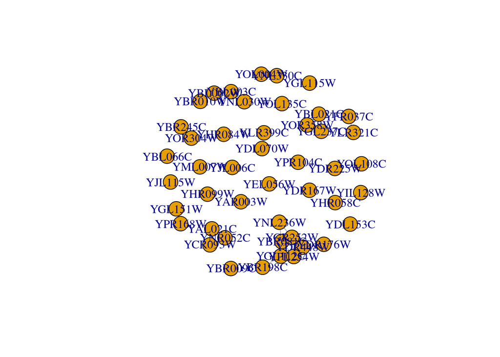

```r
plot(highconfRegNet)
```

Η συγκεκριμένη οπτικοποίηση δεν είναι ικανοποιητική καθώς τα ονόματα των κόμβων επικαλύπτονται και οι ακμές δεν είναι ευδιάκριτες. H $plot()$ επιτρέπει την προσαρμογή μιας σειράς από επιπλέον παραμέτρους και τροποποιήσεις στην οπτικοποίηση, ανάλογα με τις συνθήκες. Στην παρακάτω εντολή προσθέτουμε μια σειρά από τέτοιες παραμέτρους με τις οποίες προσαρμόζουμε τα μεγέθη και τα χρώματα στους κόμβους, τα πάχη των ακμών και τη γραμματοσειρά των ετικετών.

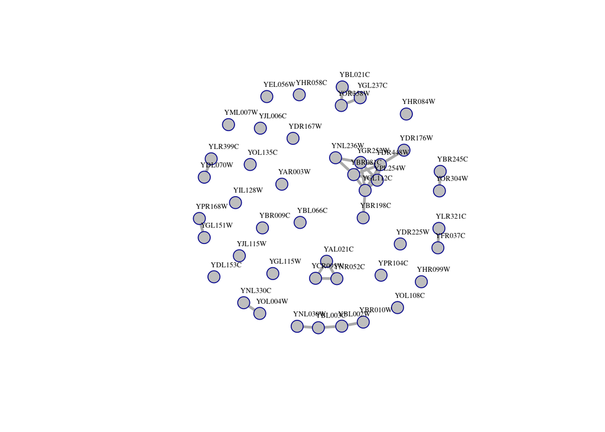

```r
plot(highconfRegNet, vertex.color="grey", vertex.size=10, vertex.frame.color="dark blue", vertex.label.color="black", vertex.label.cex=0.5, vertex.label.dist=2, edge.curved=0, edge.width=3)
```

Ακόμα κι έτσι η απεικόνιση του δικτύου έχει κάποια προβλήματα που θα μπορούσαν να λυθούν με μια πιο αποτελεσματική διάταξη των κόμβων. Η $igraph()$ διαθέτει μια σειρά από συναρτήσεις της κατηγορίας $layout()$, οι οποίες επιτρέπουν την βελτιστοποιημένη τοποθέτηση των κόμβων στον χώρο με βάση διαφορετικές μαθηματικές και στατιστικές προσεγγίσεις. Ένα παράδειγμα για το πώς χρησιμοποιούμε τέτοιες συναρτήσεις φαίνεται παρακάτω με την $layout\_with\_kk()$ που χρησιμοποιεί τον αλγόριθμο των Kamada-Kawai, ο οποίος βασίζεται σε φυσικά μοντέλα ελατηρίων.

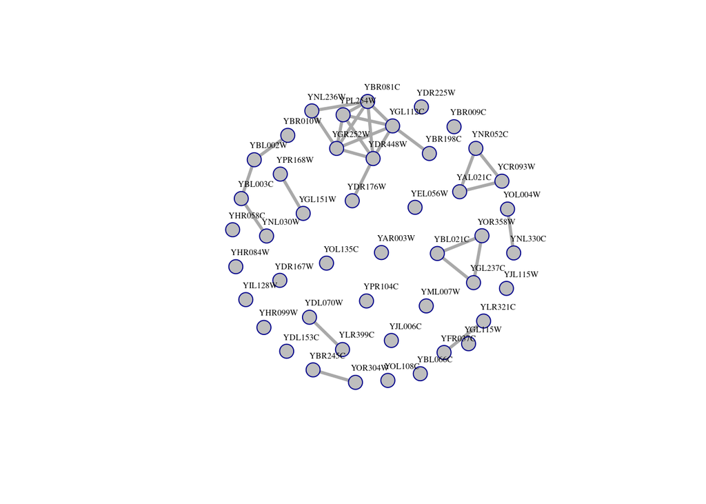

```r
l <- layout_with_kk(highconfRegNet)
plot(highconfRegNet, edge.arrow.size=.5, vertex.color="grey", vertex.size=10, vertex.frame.color="dark blue", vertex.label.color="black", vertex.label.cex=0.5, vertex.label.dist=2, edge.curved=0,  edge.width=3, layout=l)
```

Ανάλογα με την πυκνότητα και τη διάταξη του δικτύου του, ο χρήστης καλείται να επιλέξει μεταξύ των πολυάριθμων συναρτήσεεων $layout$. Μια πιο απλή σύνταξη είναι η συνάρτηση layout να ενσωματωθεί στην $plot()$ όπως στα παρακάτω παραδείγματα.

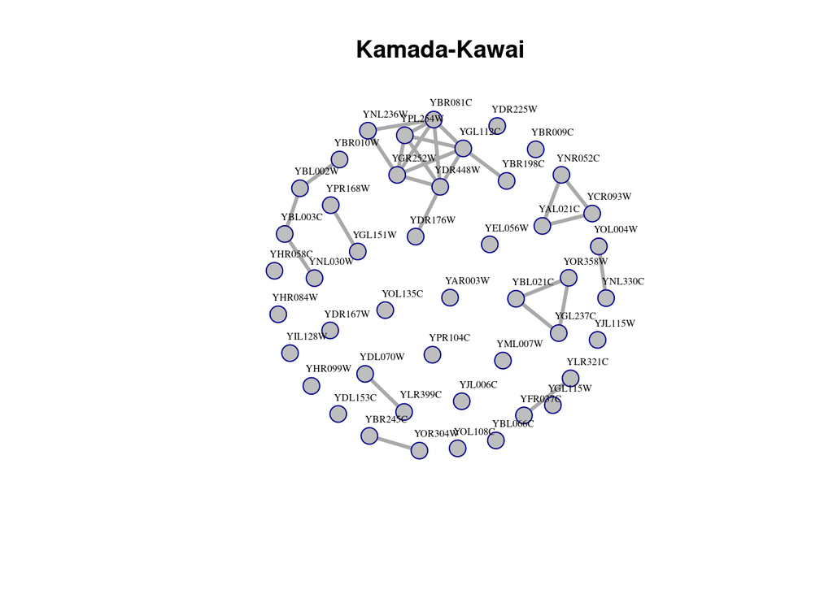

```r
plot(highconfRegNet, edge.arrow.size=.5, vertex.color="grey", vertex.size=10, vertex.frame.color="dark blue", vertex.label.color="black", vertex.label.cex=0.5, vertex.label.dist=2, edge.curved=0,  edge.width=3, layout=layout_with_kk, main="Kamada-Kawai")
```

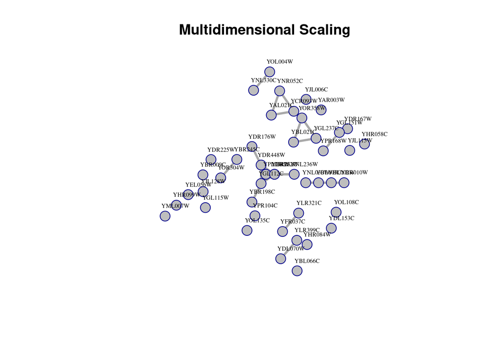

```r
#
plot(highconfRegNet, edge.arrow.size=.5, vertex.color="grey", vertex.size=10, vertex.frame.color="dark blue", vertex.label.color="black", vertex.label.cex=0.5, vertex.label.dist=2, edge.curved=0,  edge.width=3, layout=layout_with_mds, main="Multidimensional Scaling")
```

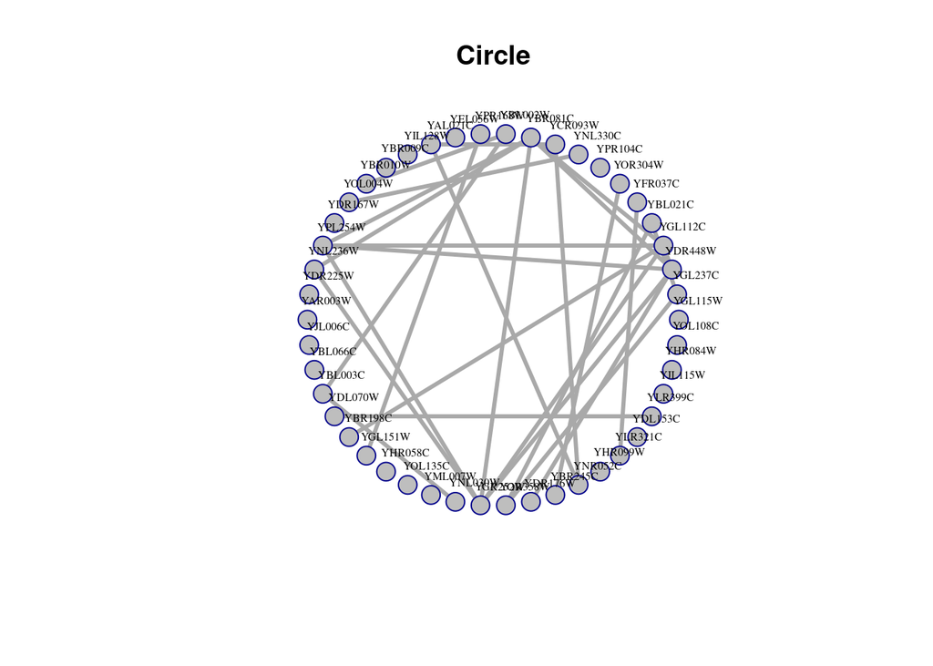

```r
#
plot(highconfRegNet, edge.arrow.size=.5, vertex.color="grey", vertex.size=10, vertex.frame.color="dark blue", vertex.label.color="black", vertex.label.cex=0.5, vertex.label.dist=2, edge.curved=0,  edge.width=3, layout=layout.circle, main="Circle")
```

Ακόμα κι έτσι υπάρχει αρκετό περιθώριο για βελτίωση. Θα επανέλθουμε στην οπτικοποίηση για να δούμε πώς μπορούν να μας βοηθήσουν σε αυτή διάφορες στατιστικές και τοπολογικές ιδιότητες των δικτύων.

## 17.6 Τοπολογικά χαρακτηριστικά δικτύων

H επιστήμη των δικτύων μελετά μια σειρά από ιδιότητες που αντανακλούν τα χαρακτηριστικά του φαινομένου από το οποίο έχουν προκύψει. Οι ιδιότητες αυτές χωρίζονται σε δύο κατηγορίες, τις τοπολογικές και τις στατιστικές. Παρότι μεταξύ τους είναι αρκετά συνδεδεμένες, μπορούμε να προσδιορίσουμε τις τοπολογικές ιδιότητες ως εκείνες που αφορούν το σχήμα και τις διάστασεις του δικτύου, ενώ οι στατιστικές, που θα δούμε στη συνέχεια, αντανακλούν στοιχεία της οργάνωσης και της δομής του.

### 17.6.1 Μέγεθος και πυκνότητα δικτύου

Το **μέγεθος** ενός δικτύου ορίζεται ως ο *αριθμός των κόμβων* του και όπως έχουμε δει, μπορούμε εύκολα να το προσδιορίσουμε απαριθμώντας το αποτέλεσμα της $V()$.

```r
length(V(highconfNet))
```

```
## [1] 988
```

H πυκνότητα ενός δικτύου είναι κάτι αρκετά διαφορετικό και βασίζεται όχι στους κόμβους αλλά στις ακμές. Ένα δίκτυο μεγάλου μεγέθους (μεγάλου αριθμού κόμβων) μπορεί να έχει ελάχιστες συνδέσεις (ακμές) μεταξύ των στοιχείων του, την ίδια στιγμή που ένα πολύ μικρότερο μπορεί να είναι πολύ πυκνότερο. Την έννοια αυτή, της **πυκνότητας του δικτύου**, την ορίζουμε ποσοτικά ως *το πηλίκο των ακμών που υπάρχουν στο δίκτυο, προς τον αριθμό των ακμών που θα είχε ένα πλήρως διασυνδεδεμένο (fully-connected) δίκτυο ίσου μεγέθους*. Ένα πλήρως διασυνδεδεμένο δίκτυο είναι ένα δίκτυο στο οποίο κάθε στοιχείο συνδέεται άμεσα με καθένα από τα υπόλοιπα. Ο αριθμός των συνδέσεων ενός πλήρως διασυνδεδεμένου δικτύου είναι:
$$E_{exp}(n) = {n(n-1) \over 2}$$

Και κατά συνέπεια η πυκνότητα ορίζεται ως:
$$density = {E(n) \over E_{exp}(n)}$$

H R έχει μια συνάρτηση για αυτόν το σκοπό που ονομάζεται $edge\_density()$ και που μπορούμε να καλέσουμε απευθείας στο δίκτυο.

```r
edge_density(highconfNet, loops = FALSE)
```

```
## [1] 0.005035092
```

Η παράμετρος loops=F, ζητάει από τη συνάρτηση να μην υπολογιστούν οι ακμές που ενώνουν ένα αντικείμενο με τον εαυτό του. Για να πάρουμε μια ιδέα για το πόσο μεγάλη ή όχι είναι η τιμή της πυκνότητας του βιολογικού δικτύου, ας δούμε ποια είναι η αντίστοιχη για το κοινωνικό δίκτυο των δέκα ατόμων των αρχικών μας παραδειγμάτων.

```r
edge_density(mynet, loops=F)
```

```
## [1] 0.3111111
```

Η οποία βλέπουμε ότι είναι σχεδόν δύο τάξεις μεγέθους μεγαλύτερη, κάτι που μας υποδεικνύει ότι το δίκτυο πρωτεϊνικών αλληλεπιδράσεων είναι εξαιρετικά αραιό.

### 17.6.2 Αποστάσεις, διάμετρος και συντομότερα μονοπάτια

Μια άλλη κατηγορία τοπολογικών χαρακτηριστικών έχει να κάνει με την διασύνδεση των κόμβων σε επίπεδο αποστάσεων μεταξύ τους. Μπορούμε να φανταστούμε ένα δίκτυο ως μια κατασκευή που μας επιτρέπει να μετακινηθούμε από κόμβο σε κόμβο και μια εύλογη ερώτηση είναι πόσο σύντομα μπορούμε να πάμε από έναν δεδομένο κόμβο Χ σε έναν άλλο κόμβο Υ. Ορίζουμε ως **απόσταση δύο κόμβων Χ, Υ** τον *αριθμό των κόμβων από τους οποίους θα περάσουμε πραγματοποιώντας τη συντομότερη διαδρομή μεταξύ Χ και Υ*. Στην περίπτωση που οι Χ και Υ δεν συνδέονται, δηλαδή δεν υπάρχει τρόπος να φτάσουμε από τον έναν στον άλλον, τότε η απόστασή του ορίζεται ως άπειρη (Inf). Μέσω της συνάρτησης $distances()$ της $igraph()$ μπορούμε να πάρουμε όλες τις αποστάσεις όλων των κόμβων μεταξύ τους.

```r
ds<-distances(highconfNet, v=V(highconfNet), to=V(highconfNet), mode = "all", algorithm = "dijkstra")
ds[1:10,1:10]
```

```
##         YLR197W YOR039W YDR473C YOR332W YER090W YDR394W YER021W YPR029C YIL106W
## YLR197W       0       2     Inf       5       4       3       4     Inf     Inf
## YOR039W       2       0     Inf       6       4       3       4     Inf     Inf
## YDR473C     Inf     Inf       0     Inf     Inf     Inf     Inf     Inf     Inf
## YOR332W       5       6     Inf       0       4       3       3     Inf     Inf
## YER090W       4       4     Inf       4       0       2       3     Inf     Inf
## YDR394W       3       3     Inf       3       2       0       1     Inf     Inf
## YER021W       4       4     Inf       3       3       1       0     Inf     Inf
## YPR029C     Inf     Inf     Inf     Inf     Inf     Inf     Inf       0     Inf
## YIL106W     Inf     Inf     Inf     Inf     Inf     Inf     Inf     Inf       0
## YKL166C       4       4     Inf       6       5       3       4     Inf     Inf
##         YKL166C
## YLR197W       4
## YOR039W       4
## YDR473C     Inf
## YOR332W       6
## YER090W       5
## YDR394W       3
## YER021W       4
## YPR029C     Inf
## YIL106W     Inf
## YKL166C       0
```

Στην σύνταξη που βλέπετε παραπάνω, ορίζουμε μεταξύ ποιων ζευγών κόμβων θέλουμε να υπολογιστούν οι αποστάσεις καθώς και τον αλγόριθμο για τον υπολογισμό τους. Ο αλγόριθμος του Edsger Dijkstra είναι ίσως ο πιο διαδεδομένος τρόπος για αυτόν τον υπολογισμό. Στο παραπάνω υποσύνολο των αποστάσεων μεταξύ των πρώτων δέκα πρωτεϊνών (θυμηθείτε ότι ο συνολικός αριθμός τους είναι (ΝχΝ)/2) βλέπετε ένα σημαντικό ποσοστό Ιnf, που υποδηλώνει μη συνδεδεμένους κόμβους, μια ακόμη υπενθύμιση του πόσο αραιό είναι το δίκτυό μας.

H κατανομή των αποστάσεων είναι μια ιδιότητα που αποτυπώνει σε ικανοποιητικό βαθμό την τοπολογία του δικτύου σε ό,τι αφορά τις ακμές. Μπορούμε να την πάρουμε αυτόματα με την κλήση της συνάρτησης $distance\_table()$.

```r
distance_table(highconfNet)
```

```
## $res
##  [1]  2455  7794 18440 31603 35530 30933 20812 10720  4528  1527   415    86
## [13]    11     1
##
## $unconnected
## [1] 322723
```

To output αναφέρει το πλήθος των ζευγών κόμβων με απόσταση 1, 2, 3 κ.ο.κ. Από την παραπάνω απάντηση βλέπουμε ότι υπάρχουν αποστάσεις από 1 έως 14 (η μέγιστη), ενώ >320000 ζεύγη δεν συνδέονται καθόλου (d=Inf). Η μέση απόσταση αποτυπώνει ένα αριθμητικό μέγεθος που μπορεί να αποδώσει σε κάποιο βαθμό τις διαστάσεις και τη συνδεσιμότητα του δικτύου. Η αντίστοιχη συνάρτηση είναι η $mean\_distance()$.

```r
mean_distance(highconfNet)
```

```
## [1] 5.193916
```

Ένα μέγεθος που έχει ίσως μεγαλύτερη σημασία σε κάποιες περιπτώσεις είναι *η μεγαλύτερη απόσταση εντός του δικτύου*, η οποία ονομάζεται **διάμετρος** του δικτύου. Μπορούμε εύκολα να την υπολογίσουμε με την γνωστή συνάρτηση $max()$ αφαιρώντας τις τιμές που είναι άπειρες και όπως είδαμε παραπάνω είναι ίση με 14.

```r
max(ds[which(ds!=Inf)])
```

```
## [1] 14
```

Ποια είναι όμως σε κάθε περίπτωση η διαδρομή; Από ποιους ακριβούς κόμβους διέρχεται; Mε δύο δεδομένες πρωτεΐνες μπορούμε να εντοπίσουμε όχι μόνο την απόσταση αλλά το ακριβές συντομότερο μονοπάτι κόμβων που μας οδηγεί από τη μία στην άλλη. Η συνάρτηση είναι η $shortest\_paths()$. Mε την παρακάτω σύνταξη παίρνουμε τόσο το μονοπάτι σε κόμβους (vpath) όσο και σε ακμές (epath). Εναλλακτικά μπορούμε να επιλέξουμε ένα από τα δύο με την παράμετρο output.

```r
shortest_paths(highconfNet, from="YIR034C", to="YLR197W",  algorithm = "dijkstra", output="both")
```

```
## $vpath
## $vpath[[1]]
## + 8/988 vertices, named, from 9dccb98:
## [1] YIR034C YBR218C YGL026C YER090W YDR127W YMR012W YMR049C YLR197W
##
##
## $epath
## $epath[[1]]
## + 7/2455 edges from 9dccb98 (vertex names):
## [1] YBR218C--YIR034C YGL026C--YBR218C YER090W--YGL026C YER090W--YDR127W
## [5] YDR127W--YMR012W YMR049C--YMR012W YLR197W--YMR049C
##
##
## $predecessors
## NULL
##
## $inbound_edges
## NULL
```

Σημειώνεται εδώ ότι η $shortest\_paths()$ λειτουργεί και με λίστες πρωτεϊνών αντί για ένα απλό ζεύγος.

```
Ερωτήσεις-Ασκήσεις
1. Να υπολογίσετε το μέγεθος, την πυκνότητα και τη διάμετρο του δικτύου karate.
2. Στο σύνολο δεδομένων UKfaculty από τη βιβλιοθήκη igraphdata να υπολογίσετε την κατανομή των αποστάσεων και την αναπαραστήσετε γραφικά.
3. Ποιος είναι ο ελάχιστος και ποιος ο μέγιστος αριθμός ακμών ενός μη-κατευθυνόμενου δικτύου με 10 κόμβους;
```

## 17.7 Στατιστικές Ιδιότητες Δικτύων

Όπως αναφέραμε και παραπάνω, τα δίκτυα διαθέτουν μια σειρά από στατιστικές ιδιότητες, οι οποίες αντανακλούν την εσωτερική τους δομή, καθώς και τη φύση των φαινομένων που περιγράφουν. Η αναλυτική περιγραφή αυτών των σχέσεων ξεφεύγει από τους σκοπούς αυτού του βιβλίου, αλλά αρκεί να πούμε ότι μια σειρά από αναδυόμενες ιδιότητες (emergent properties) πολλών πολύπλοκων συστημάτων μπορούν να μελετηθούν μέσα από τη στατιστική ανάλυση των αντίστοιχων δικτύων. Στην ενότητα αυτή θα περιγράψουμε τις πιο βασικές από αυτές και θα δούμε πώς μπορούμε να τις υπολογίσουμε μέσω της R αλλά και να τις χρησιμοποιήσουμε για να βελτιώσουμε τις αναπαραστάσεις των δικτύων σε γραφήματα με μεγαλύτερη περιγραφική ικανότητα.

### 17.7.1 Βαθμός κόμβων

Μια βασική κατηγορία στατιστικών ιδιοτήτων είναι τα μέτρα κεντρικότητας (centrality measures), ποοσοτικές αποτυπώσεις δηλαδή του βαθμού στον οποίο συγκεκριμένοι κόμβοι είναι κεντρικοί για το δίκτυο. Είναι εύκολο να καταλάβει κανείς ότι οι κεντρικοί κόμβοι έχουν μεγαλύτερη σημασία για ένα δίκτυο καθώς είναι υπεύθυνοι για μεγαλύτερο, αναλογικά, βαθμό συνδέσεων. Το πιο απλό μέτρο κεντρικότητας είναι ο **βαθμός κόμβου**. Ορίζουμε βαθμό (degree) ενός κόμβου *το σύνολο των ακμών με τις οποίες διασυνδέεται με άλλους κόμβους στο δίκτυο*. Ανάλογα με το αν το δίκτυο είναι κατευθυνόμενο ή όχι, ο βαθμός ενός δεδομένου κόμβου μπορεί να διακριθεί σε βαθμό εισερχόμενων και εξερχόμενων ακμών. Το άθροισμα των δύο ισούται σε αυτήν την περίπτωση με το συνολικό βαθμό του κόμβου. Στην R μπορούμε να τους υπολογίσουμε με την συνάρτηση $degree()$.

```r
degree(mynet, mode="total")
```

```
## Christoforos      Giorgos      Aggelos      Dimitra     Katerina        Maria
##            6            3            2            3            4            1
##        Eleni Konstantinos    Vassiliki        Nikos
##            3            2            2            2
```

Με την παράμετρο mode ζητάμε από την R να υπολογίσει όλους, τους εισερχόμενους ή τους εξερχόμενους μόνο κόμβους. Εννοείται ότι οι δύο τελευταίοι μπορούν να υπολογιστούν σε κατευθυνόμενα δίκτυα.

```r
print("Incoming Nodes")
```

```
## [1] "Incoming Nodes"
```

```r
degree(mynet2, mode="in")
```

```
## Christoforos      Giorgos      Aggelos      Dimitra     Katerina        Maria
##            0            3            2            2            3            0
##        Eleni Konstantinos    Vassiliki        Nikos
##            1            1            1            1
```

```r
#
print("Outcoming Nodes")
```

```
## [1] "Outcoming Nodes"
```

```r
degree(mynet2, mode="out")
```

```
## Christoforos      Giorgos      Aggelos      Dimitra     Katerina        Maria
##            6            0            0            1            1            1
##        Eleni Konstantinos    Vassiliki        Nikos
##            2            1            1            1
```

Ο βαθμός των κόμβων είναι μια ιδιότητα που μπορούμε να εκμεταλλευτούμε για να απλοποιήσουμε ένα δίκτυο, αφαιρώντας τους απομονωμένους κόμβους, δηλαδή τους κόμβους που δεν έχουν ακμές με άλλα τμήματα του δικτύου. Κάτι τέτοιο έχει πρακτική εφαρμογή σε καλύτερες και πιο εύληπτες απεικονίσεις όπως βλέπουμε παρακάτω για το δίκτυο των ρυθμιστικών πρωτεϊνών του σακχαρομήκυτα που εξετάσαμε νωρίτερα. Αρχικά θα υπολογίσουμε τον βαθμό των κόμβων του δικτύου και θα τον αποδώσουμε στους κόμβους ως ιδιότητα (attribute).

```r
V(highconfRegNet)$degree<-degree(highconfRegNet)
```

Έπειτα θα αφαιρέσουμε από το δίκτυο τους κόμβους μηδενικού βαθμού.

```r
isolated<-which(V(highconfRegNet)$degree==0)
highconfRegNetSmall <- delete.vertices(highconfRegNet, isolated)
```

Τέλος, θα αναπαραστήσουμε γραφικά το μικρότερο υποδίκτυο, χωρίς τους απομομονωμένους κόμβους.

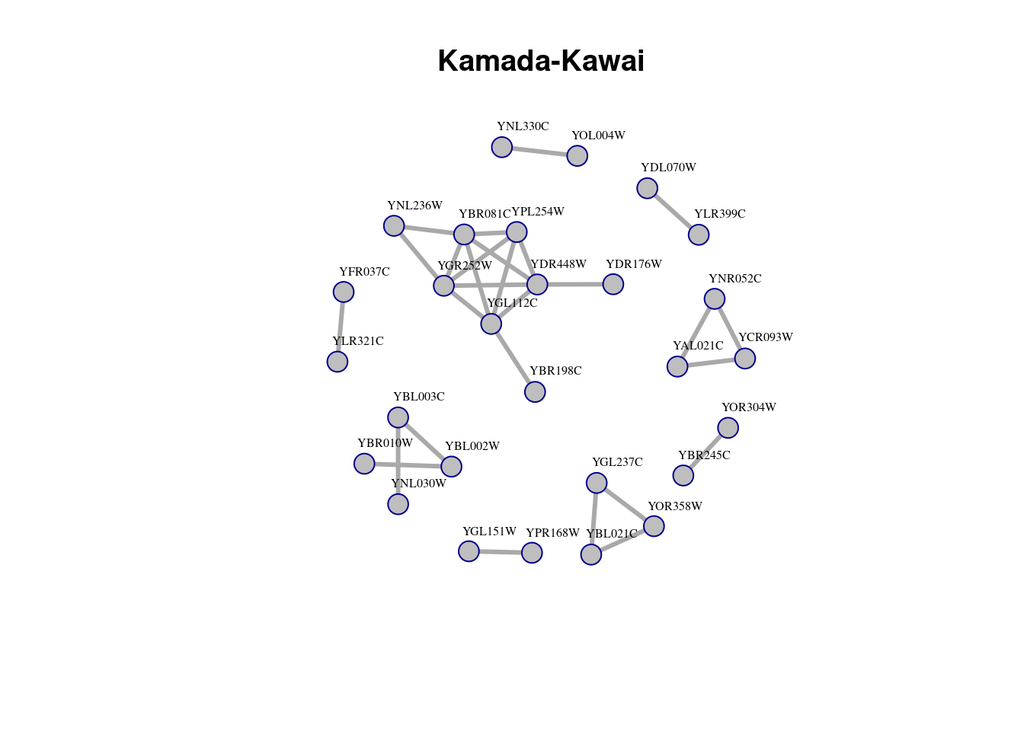

```r
plot(highconfRegNetSmall, edge.arrow.size=.5, vertex.color="grey", vertex.size=10, vertex.frame.color="dark blue", vertex.label.color="black", vertex.label.cex=0.5, vertex.label.dist=2, edge.curved=0,  edge.width=3, layout=layout_with_kk, main="Kamada-Kawai")
```

Τα μέτρα κεντρικότητας, ως ιδιότητες, μπορούν να χρησιμοποιηθούν για να βελτιώσουν περαιτέρω την οπτικοποίηση. Μια χαρακτηριστική προσαρμογή είναι αυτή που τροποποιεί το μέγεθος των κόμβων στο γράφημα σε αναλογία με τον βαθμό τους (ή κάποιο άλλο μέτρο κεντρικότητας). Μπορούμε να κάνουμε κάτι τέτοιο στην $plot()$ με την παράμετρο vertex.size, όπως βλέπουμε παρακάτω.

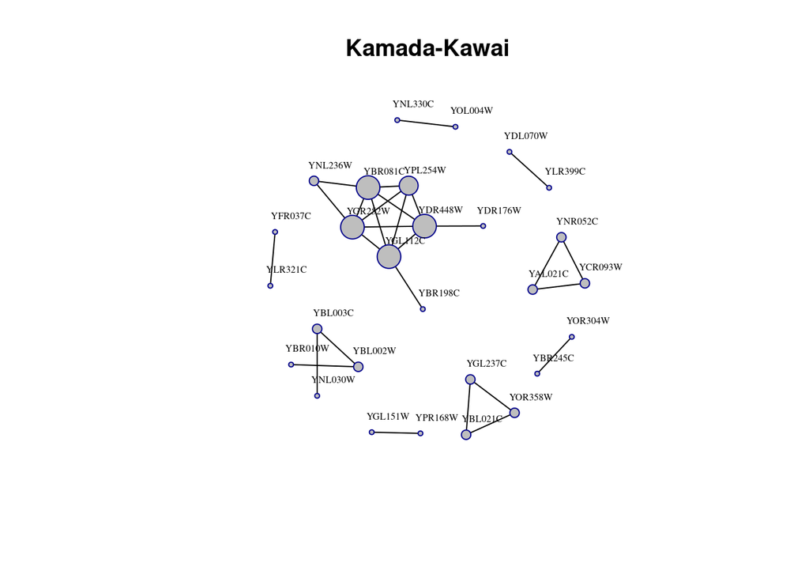

```r
plot(highconfRegNetSmall, edge.color="black", vertex.color="grey", vertex.frame.color="dark blue", vertex.label.color="black", vertex.label.cex=0.5, vertex.label.dist=2, edge.width=1, layout=layout_with_kk, main="Kamada-Kawai", vertex.size=V(highconfRegNetSmall)$degree*3)
```

Στο παράδειγμα έχουμε κάνει μια επιπλέον γραμμική προσαρμογή πολλαπλασιάζοντας την τιμή του βαθμού επι 3. Αντίστοιχες προσαρμογές μπορούν να γίνουν με λογαρίθμηση ή με άλλες μη γραμμικές μετατροπες στην περίπτωση που το εύρος των τιμών κεντρικότητας είναι πολύ μεγάλο, σε πιο πολύπλοκα δίκτυα.

### 17.7.2 Κεντρικότητα Εγγύτητας (closeness centrality)

Εκτός από τον βαθμό κόμβου υπάρχουν και άλλα μέτρα κεντρικότητας που αποτυπώνουν την σημασία των κόμβων στη διασυνδεσιμότητα του δικτύου. H **κεντρικότητα εγγύτητας** (closeness centrality) ορίζεται ως *το αντίστροφο του αθροίσματος των απόστασεων του κόμβου απ’ όλους τους άλλους κόμβους*. Η απόσταση εδώ ορίζεται, όπως είδαμε παραπάνω, ως το μήκος του διανύσματος της συντομότερης διαδρομής. Έτσι η κεντρικότητα εγγύτητας του κόμβου Α σ’ ένα δίκτυο με Ν κόμβους δίνεται από την εξίσωση:
$$C(A) = {1 \over
\sum_{i=1}^{i=N} σ(Α)_i}$$
όπου $σ(Α)_i$ είναι η συντομότερη απόσταση του κόμβου $Α$ από τον $i$. Στην R η closeness centrality δίνεται από τη συνάρτηση $closeness()$. Παρακάτω την υπολογίζουμε αποκλειστικά για τους διασυνδεδεμένους κόμβους.

```r
closeness(highconfRegNetSmall, normalized = F)
```

```
##    YGL237C    YDR448W    YGL112C    YBL021C    YFR037C    YOR304W    YNL330C
## 0.50000000 0.11111111 0.11111111 0.50000000 1.00000000 1.00000000 1.00000000
##    YCR093W    YBR081C    YBL002W    YPR168W    YAL021C    YBR010W    YOL004W
## 0.50000000 0.11111111 0.25000000 1.00000000 0.50000000 0.16666667 1.00000000
##    YPL254W    YNL236W    YBL003C    YDL070W    YBR198C    YGL151W    YNL030W
## 0.10000000 0.07142857 0.25000000 1.00000000 0.06666667 1.00000000 0.16666667
##    YGR252W    YOR358W    YDR176W    YBR245C    YNR052C    YLR321C    YLR399C
## 0.11111111 0.50000000 0.06666667 1.00000000 0.50000000 1.00000000 1.00000000
```

H παράμετρος normalized=F υπολογίζει την κεντρικότητα με τον μαθηματικό τύπο που είδαμε παραπάνω. Αλλαγή της σε normalized=Τ υπολογίζει την κανονικοποιημένη κεντρικότητα στην οποία αντί για το άθροισμα στον παρονομαστή έχουμε τη μέση τιμή των αποστάσεων.  
Ο ορισμός της κεντρικότητας εγγύτητας είναι τέτοιος που δεν είναι είναι υποχρεωτικά ανάλογος του βαθμού κόμβων. Δείτε π.χ. πώς συσχετίζονται αρνητικά τα δύο μεγέθη για το συγκεκριμένο δίκτυο.

```r
cor(closeness(highconfRegNetSmall, normalized = F), V(highconfRegNetSmall)$degree)
```

```
## [1] -0.5960849
```

Αυτό σημαίνει ότι ένας κόμβος μπορεί να έχει μεγάλο βαθμό, δηλαδή πολλούς πρώτους γείτονες αλλά να μην είναι και υποχρεωτικά στενά διασυνδεδεμένος και με άλλους κομβους (δεύτερους, τρίτους γείτονες κλπ). Σε δίκτυα με την κάπως αποσπασματική δομή που έχει το δίκτυο πρωτεϊνικών αλληλεπιδράσεων αυτή η αντίστροφη σχέση είναι αναμενόμενη.

Μπορούμε να δούμε τη σχέση αυτή να αλλάζει σε δίκτυα με μεγαλύτερη διασυνδεσιμότητα. Στο σημείο αυτό θα εισαγάγουμε ένα άλλο κοινωνικό δίκτυο. Το δίκτυο της σχολής καράτε του Zachary που παίρνει το όνομά του από τον Wayne Zachary που εισήγαγε και παρουσίασε αυτό το δίκτυο σε μια σημαντική δημοσίευση της θεωρίας δικτύων (Wayne W. Zachary. An Information Flow Model for Conflict and Fission in Small Groups. Journal of Anthropological Research. 33, 4, 452-473, 1977). Το συγκεκριμένο δίκτυο υπάρχει ενσωματωμένο στην $igraphdata$ ως karate. Παρακάτω το φορτώνουμε και το οπτικοποιούμε.

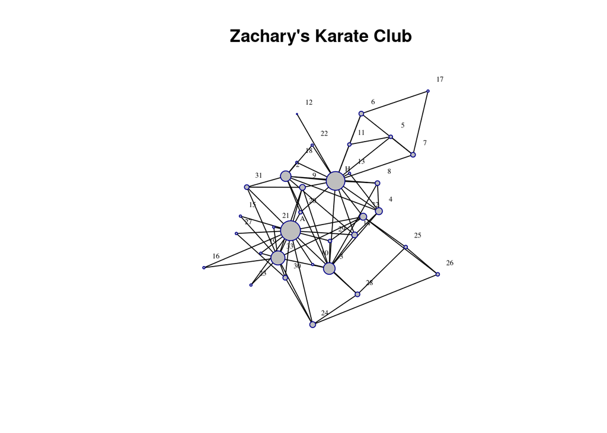

```r
data(karate)
V(karate)$degree <- degree(karate)
plot(karate,edge.color="black", vertex.color="grey", vertex.frame.color="dark blue", vertex.label.color="black", vertex.label.cex=0.5, vertex.label.dist=2, edge.curved=0,  edge.width=1, layout=layout_with_kk, main="Zachary's Karate Club", vertex.size=V(karate)$degree)
```

Mπορείτε και με μια απλή επισκόπηση να διακρίνετε την αυξημένη πυκνότητά του σε σχέση με το δίκτυο των πρωτεϊνικών αλληλεπιδράσεων. Στη συνέχεια υπολογίζουμε την συσχέτιση κεντρικότητας εγγύτητας και του βαθμού κόμβων.

```r
cor(closeness(karate), degree(karate))
```

```
## [1] 0.5860469
```

Βλέπουμε ότι σε ένα πιο στενά διασυνδεδεμένο δίκτυο η σχέση μεταξύ των δύο μέτρων κεντρικότητας είναι θετική.

### 17.7.3 Διακεντρικότητα (betweenness centrality)

Ένα τρίτο μέτρο κεντρικότητας είναι η **διακεντρικότητα** (betweenness centrality). Ως διακεντρικότητα ορίζεται *ο λόγος των συντομότερων διαδρομών που διέρχονται από έναν κόμβο προς το σύνολο των συντομότερων διαδρομών*. Μπορούμε να την υπολογίσουμε απευθείας με την αντίστοιχη συνάρτηση $betweenness()$, αυτή τη φορά με την παράμετρο normalized=T για να αποδοθεί αυτή η έννοια του σταθμισμένου λόγου.

```r
V(karate)$betweenness <- betweenness(karate, normalized = T)
V(karate)$betweenness
```

```
##  [1] 0.4737689394 0.0640151515 0.0694128788 0.0025252525 0.0009469697
##  [6] 0.0293560606 0.0293560606 0.0000000000 0.0248106061 0.0137941919
## [11] 0.0009469697 0.0000000000 0.0000000000 0.0022727273 0.0000000000
## [16] 0.0000000000 0.0000000000 0.0304924242 0.0056818182 0.2406565657
## [21] 0.0000000000 0.0000000000 0.0000000000 0.0018939394 0.0640782828
## [26] 0.0009469697 0.0000000000 0.0123106061 0.0191287879 0.0000000000
## [31] 0.0056818182 0.1256313131 0.0722222222 0.3967803030
```

Και να την οπτικοποιήσουμε προβάλλοντάς την στο μέγεθος των κόμβων.

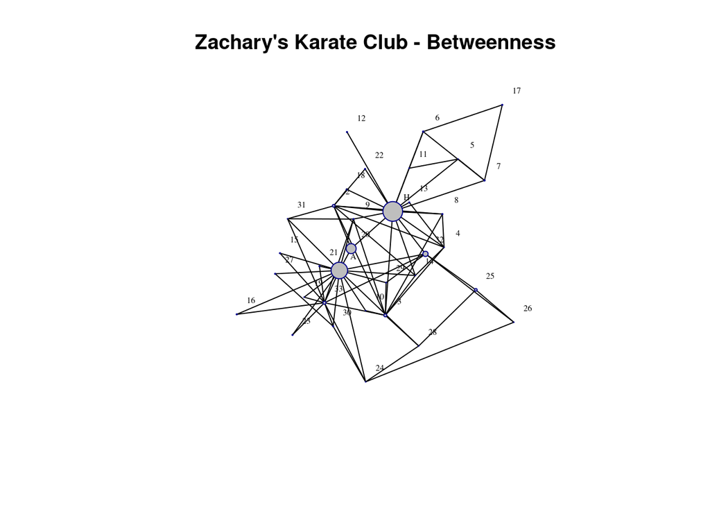

```r
plot(karate,edge.color="black", vertex.color="grey", vertex.frame.color="dark blue", vertex.label.color="black", vertex.label.cex=0.5, vertex.label.dist=2, edge.curved=0,  edge.width=1, layout=layout_with_kk, main="Zachary's Karate Club - Betweenness", vertex.size=V(karate)$betweenness*30)
```

### 17.7.4 Συντελεστής Συσσωμάτωσης και Ομοφιλία

Μια στατιστική ιδιότητα των δικτύων με μεγάλη σημασία για την συνεκτικότητά τους, είναι η πιθανότητα δύο κόμβων να είναι γείτονες μεταξύ τους εφόσον είναι γείτονες ενός τρίτου κόμβου. Η ιδιότητα αυτή αποτυπώνεται σε ένα μέτρο που ονομάζεται **συντελεστής συσσωμάτωσης** (clustering coefficient) ή **μεταβατικότητα** (transitivity). Η ποσότητα αυτή υπολογίζεται για κάθε κόμβο ως *ο λογος των πρώτων γειτόνων ενός κόμβου που είναι και μεταξύ τους πρώτοι γείτονες*. Με μία έννοια, ο συντελεστής συσσωμάτωσης είναι ένα μέτρο κεντρικότητας αλλά και διασυνδεσιμότητας ταυτόχρονα και από αυτήν την άποψη είναι πολύ χρήσιμος για να αποτυπώσει το πόσο “σφιχτά” συνδεδεμένο είναι ένα δίκτυο. Στην R η συνάρτηση $transitivity()$ υπολογίζει τη μέση τιμή του για όλο το δίκτυο με την παράμετρο type=“global” και χωρίς την εισαγωγή συγκεκριμένων κόμβων.

```r
transitivity(karate, type="global")
```

```
## [1] 0.2556818
```

Μπορούμε να υπολογίσουμε τον βαθμό συσσωμάτωσης για δεδομένο κόμβο ή κόμβους θέτοντας την παράμετρο type=“local” και δίνοντας τα ονόματα των κόμβων ως διάνυσμα στην παράμετρο vids (vertex ids).

```r
transitivity(karate,type="local", vids = c("Actor 3", "Actor 11", "Actor 21"))
```

```
## [1] 0.2444444 0.6666667 1.0000000
```

Αν ο συντελεστής συσσωμάτωσης μας δίνει το βαθμό στον οποίο ένας κόμβος μπορεί να “επάγει” συνδέσεις μεταξύ των πρώτων γειτόνων η **ομοφιλία** ή **καταταξιμότητα** (assortativity) είναι μια βασική ιδιότητα του κάθε δικτύου, που αντανακλά την τάση των κόμβων που είναι πρώτοι γείτονες να μοιράζονται κάποια άλλη ιδιότητα. Η καταταξιμότητα είναι στην ουσία ένας *συντελεστής συσχέτισης ενός οποιουδήποτε ποσοτικού ή ποιοιτικού χαρακτηριστικού μεταξύ ζευγών κόμβων που είναι πρώτοι γείτονες*. Ως τέτοιος συντελεστής προφανώς αναφέρεται συνολικά στο δίκτυο, καθώς δεν έχει νόημα ο υπολογισμός του ανά κόμβο. Η συνάρτηση που η υπολογίζει την καταταξιμότητα είναι η $assortativity()$ και παίρνει σαν όρισμα την ιδιότητα των κόμβων που θέλουμε να συγκρίνουμε. Στο παρακάτω παράδειγμα δίνουμε σαν όρισμα τον βαθμό των κόμβων του δικτύου Zachary.

```r
assortativity(karate, V(karate)$degree)
```

```
## [1] -0.4756131
```

Ειδικά για τον βαθμό υπάρχει μια έτοιμη συνάρτηση που ονομάζεται $assortativity\_degree()$ και η οποία υπολογίζει τους βαθμούς και την καταταξιμότητά τους ακόμα και αν δεν έχουν προ-υπολογιστεί.

```r
assortativity_degree(karate)
```

```
## [1] -0.4756131
```

## 17.8 Ομαδοποίηση δικτύων. Πυρηνικότητα, κλίκες και κοινότητες

Τόσο οι τοπολογικές όσο και οι στατιστικές ιδιότητες των δικτύων που παρουσιάστηκαν παραπάνω μπορούν να μας βοηθήσουν να “χαρτογραφήσουμε” τη δομή, το σχήμα και την πυκνότητα του δικτύου, ώστε να καταλάβουμε περισσότερα πράγματα για την οργάνωση των στοιχείων του με βάση τα χαρακτηριστικά που περιγράφουν οι ακμές. Ουσιαστικά δηλαδή να μπορέσουμε να πούμε κάτι παραπάνω για τον τρόπο με τον οποίο αποτυπώνεται το υπο μελέτη φαινόμενο στις σχέσεις των στοιχείων που αυτό επηρεάζει.

Στο σημείο αυτό θα δούμε πώς οι στατιστικές και τοπολογικές ιδιότητες μας επιτρέπουν να διακρίνουμε ομάδες μεταξύ των κόμβων με έναν τρόπο που να αντανακλά τις μεταξύ τους σχέσεις. Οι σχετικές αναλύσεις προσομοιάζουν σε μεγάλο βαθμό τις αντίστοιχες αναλύσεις ομαδοποίησης που είδαμε στο Κεφάλαιο 15, με την διαφορά ότι εδώ εφαρμόζονται σε ποσότητες που προκύπτουν από την ανάλυση των δικτύων όπως αυτές που είδαμε παραπάνω, δηλαδή σε χαρακτηριστικά που δεν προϋπήρχαν στις οντότητες των κόμβων αλλά αναδύονται από τις μεταξύ τους σχέσεις. Με αυτόν τον τρόπο αναδεικνύεται και η σημασία της θεωρίας δικτύων στα πλαίσια της μελέτης πολύπλοκων συστημάτων καθώς μας επιτρέπει, ουσιαστικά, να μάθουμε πράγματα για το σύστημά μας που δεν μπορούσαμε να γνωρίζουμε πριν.

Στη συνέχεια θα παρουσιάσουμε κάποιες από τις πιο χαρακτηριστικές αναλύσεις ομαδοποίησης και θα δούμε πώς μπορούμε να τις ενσωματώσουμε σε οπτικοποιήσεις δικτύων. Δεν χρειάζεται να επισημάνουμε ότι σε καμία περίπτωση δεν εξαντλείται εδώ η μεγάλη γκάμα των δυνατών αναλύσεων, οι οποίες εκτείνονται σε πολύ μεγάλο βαθμό και η αναλυτική περιγραφή τους δεν θα μπορούσε να είναι αντικείμενο αυτού του βιβλίου. Ο αναγνώστης που επιθυμεί να μάθει περισσότερα, παραπέμπεται σε σχετικά, εξειδικευμένα συγγράμματα (βλ. Κεφάλαιο 1).

### 17.8.1 Κλίκες και Πυρηνικότητα

Στην προηγούμενη ενότητα συζητήσαμε για ιδιότητα του συντελεστή συσσωμάτωσης ως ενός μέτρου της τοπικής διασυνδεσιμότητας των δικτύων. Δύο χαρακτηριστικά που σχετίζονται άμεσα με τη συσσωμάτωση είναι οι **κλίκες** (cliques) και η **πυρηνικότητα** (coreness). Ως κλίκα ορίζεται *κάθε υποδίκτυο ενός δικτύου που περιλαμβάνει πλήρως διασυνδεδεμένους κόμβους*. Ανάλογα με το πόσο συσσωματωμένο είναι ένα δίκτυο, θα υπάρχουν και μεγάλες ή μικρές κλίκες σε αντίστοιχα μεγάλους ή μικρούς αριθμούς. Όπως είδαμε, ωστόσο, και στην περίπτωση των μέτρων κεντρικότητας, τα δίκτυα είναι πολύπλοκα αντικείμενα και συχνά αντανακλούν ιδιότητες που είναι αρκετά ιδιαίτερες, για παράδειγμα μπορούμε να δούμε μία τεράστια κλίκα να συνοδεύεται από απομονωμένους κόμβους σε δίκτυα με παρόμοιο βαθμό συσσωμάτωσης με άλλα όπου οι κλίκες κατανέμονται πιο ομοιόμορφα. Στην $igraph()$ η συνάρτηση για την ανάλυση κλικών ονομάζεται $cliques()$ και δρα απευθείας πάνω στο δίκτυο με παραμέτρους τα ελάχιστα και μέγιστα μεγέθη κλικών. Στην συνέχεια, ζητάμε τις κλίκες μεγέθους 5 και πάνω στο δίκτυο του Zachary.

```r
cliques(karate, min=5, max=length(V(karate)))
```

```
## [[1]]
## + 5/34 vertices, named, from 4b458a1:
## [1] Mr Hi    Actor 2  Actor 3  Actor 4  Actor 14
##
## [[2]]
## + 5/34 vertices, named, from 4b458a1:
## [1] Mr Hi   Actor 2 Actor 3 Actor 4 Actor 8
```

Mε τη συνάρτηση $clique\_size\_counts()$ η R υπολογίζει και επιστρέφει την κατανομή των κλικών ανά μέγεθος, ξεκινώντας από το 1.

```r
clique_size_counts(karate)
```

```
## [1] 34 78 45 11  2
```

Όπου βλέπουμε ότι όντως το μέγεθος 5 είναι το μέγιστο μέγεθος κλίκας στο συγκεκριμένο δίκτυο.

Μια παραπλήσια ιδιότητα είναι η **πυρηνικότητα** (coreness). Η πυρηνικότητα εκφράζει ένα υποδίκτυο με συγκεκριμένο βαθμό κόμβων και ορίζεται πάντα σαν συνάρτηση αυτού του βαθμού. Έτσι λέμε ότι *ένα υποδίκτυο με πυρηνικότητα 3 είναι το τμήμα των κόμβων ενός δικτύου που συνδέονται μεταξύ τους έχοντας βαθμό 3*. Η R προσφέρει μια συνάρτηση για τον υπολογισμό της πυρηνικότητας που αποδίδει αυτόματα την τιμή της για κάθε κόμβο και δημιουργεί μια ομαδοποίηση των κόμβων. Η συνάρτηση είναι η $coreness()$.

```r
kc <- coreness(karate, mode="all")
kc
```

```
##    Mr Hi  Actor 2  Actor 3  Actor 4  Actor 5  Actor 6  Actor 7  Actor 8
##        4        4        4        4        3        3        3        4
##  Actor 9 Actor 10 Actor 11 Actor 12 Actor 13 Actor 14 Actor 15 Actor 16
##        4        2        3        1        2        4        2        2
## Actor 17 Actor 18 Actor 19 Actor 20 Actor 21 Actor 22 Actor 23 Actor 24
##        2        2        2        3        2        2        2        3
## Actor 25 Actor 26 Actor 27 Actor 28 Actor 29 Actor 30 Actor 31 Actor 32
##        3        3        2        3        3        3        4        3
## Actor 33   John A
##        4        4
```

Όπως είπαμε μία από τις εφαρμογές των ομαδοποιήσεων είναι στην αναπαράσταση δικτύων. Παρακάτω βλέπουμε πώς μπορούμε να συμπεριλάβουμε τις τιμές πυρηνικότητας σε ένα διάγραμμα.

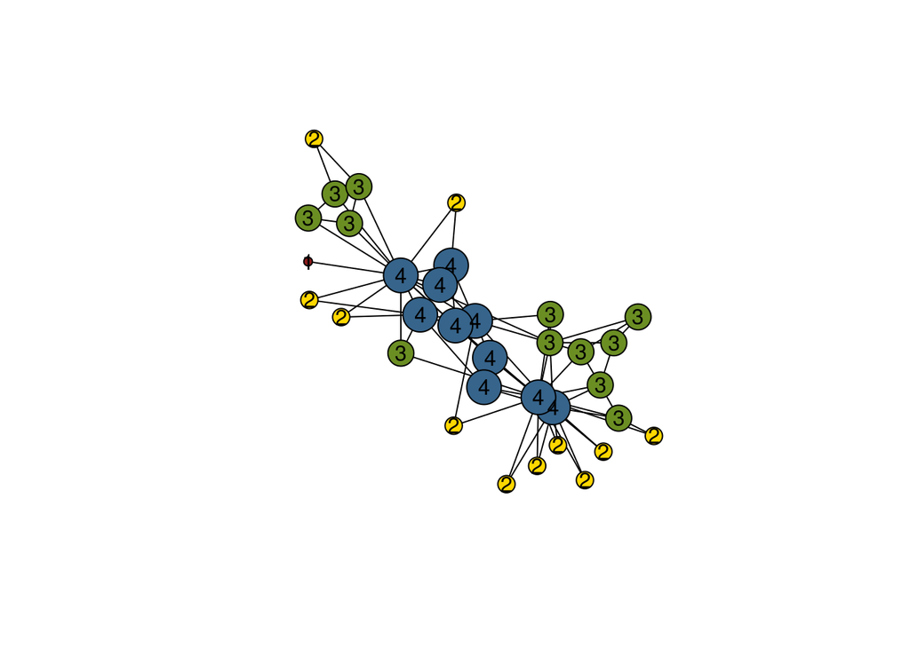

```r
colors<-c("firebrick4", "gold", "olivedrab", "steelblue4")
plot(karate, vertex.size=kc*5, vertex.label=kc, vertex.color=colors[kc], vertex.label.color="black", vertex.label.family="sans", edge.color="black")
```

Όπου βλέπουμε τους πυρήνες διαφόρων μεγεθών να αναπαρίστανται με διαφορετικό χρώμα. Είναι επίσης προφανές οτι το δίκτυο έχει έναν πυρήνα υψηλού βαθμού κόμβων και περιφερειακές ομάδες με μικρότερους.

### 17.8.2 Kοινότητες (communities)

Οι κλίκες και οι πυρήνες είναι ένας απλός τρόπος για να σταθμίσουμε δομικές ιδιότητες ενός δικτύου, ωστόσο σε πιο πολύπλοκα και πιο μεγάλα δίκτυα μπορούμε (και πρέπει) να εφαρμόσουμε πιο εκλεπτυσμένους αλγορίθμους ομαδοποίησης για την κατανομή των κόμβων του δικτύου σε ομάδες. Ονομάζουμε αυτές τις ομάδες **κοινότητες** (communities) και παρακάτω βλέπουμε πώς μπορούμε να τις δημιουργήσουμε με διαφορετικές παραλλαγές των συναρτήσεων $cluster()$ της $igraph()$. H R προσφέρει μια σειρά από τέτοιες συναρτήσεις κάθεμία από τις οποίες εφαρμόζει πολύ διαφορετικούς αλγορίθμους, τους οποίους δεν θα παρουσιάσουμε σε αυτό το σημείο. Οι πιο χαρακτηριστικοί τέτοιοι αλγόριθμοι (και οι πιο γρήγοροι) είναι οι louvain, infomap και fast_greedy. Στη συνέχεια θα τους εφαρμόσουμε στο δίκτυο του Zachary.

```r
k_louvain<-cluster_louvain(karate)
k_im<-cluster_infomap(karate)
k_fg<-cluster_fast_greedy(karate)
```

Το αποτέλεσμα αυτής της ανάλυσης είναι ένα αντικείμενο της κλάσης communities, που ουσιαστικά είναι μια ομαδοποίηση των κόμβων του δικτύου. Μια σειρά από συναρτήσεις τις $igraph()$ μας βοηθούν να εξετάσουμε την κατανομή σε ομάδες, όπως φαίνεται παρακάτω για τις κοινότητες louvain.

```r
membership(k_louvain)
```

```
##    Mr Hi  Actor 2  Actor 3  Actor 4  Actor 5  Actor 6  Actor 7  Actor 8
##        1        1        1        1        2        2        2        1
##  Actor 9 Actor 10 Actor 11 Actor 12 Actor 13 Actor 14 Actor 15 Actor 16
##        3        3        2        1        1        1        3        3
## Actor 17 Actor 18 Actor 19 Actor 20 Actor 21 Actor 22 Actor 23 Actor 24
##        2        1        3        1        3        1        3        4
## Actor 25 Actor 26 Actor 27 Actor 28 Actor 29 Actor 30 Actor 31 Actor 32
##        4        4        3        4        4        3        3        4
## Actor 33   John A
##        3        3
```

Αντίστοιχα για το μέγεθος (και ταυτόχρονα το πλήθος) των κοινοτήτων μπορούμε να χρησιμοποιήσουμε την $sizes()$.

```r
sizes(k_louvain)
```

```
## Community sizes
##  1  2  3  4
## 11  5 12  6
```

Στο παράδειγμα βλέπουμε ότι το δίκτυο οργανώνεται σε 4 διαφορετικές κοινότητες με βάση τον αλγόριθμο louvain. Ταυτόχρονα έχουμε αποδώσει μεγαλύτερα μεγέθη στους κόμβους με μεγαλύτερο βαθμό. Μπορούμε να χρησιμοποιήσουμε τις κοινότητες για μια γραφική αναπαράσταση του δικτύου με τρόπο ανάλογο αυτού που είδαμε παραπάνω για το μικρότερο δίκτυο με βάση τους πυρήνες.

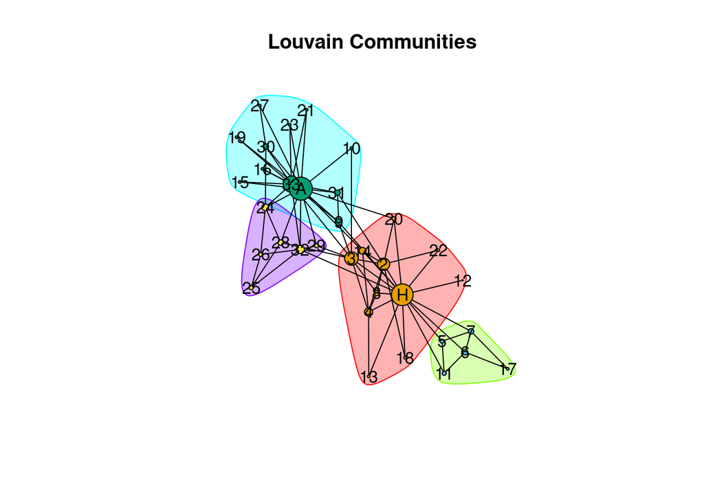

```r
plot(k_louvain, karate, vertex.size=V(karate)$degree, vertex.label.color="black", vertex.label.family="sans", edge.color="black", main="Louvain Communities")
```

Στην παραπάνω εντολή είναι σημαντικό το πρώτο όρισμα να είναι οι κοινότητες, ακολουθούμενο από το δίκτυο. Βλέπουμε ότι ο αλγόριθμος έχει εντοπίσει συγκεκριμένες, συνεκτικές υπο-ομάδες στο δίκτυο τις οποίες απεικονίζει με έναν εύληπτο τρόπο. Μπορούμε να χρησιμοποιήσουμε τις κοινότητες σε μια εναλλακτική απεικόνιση κόμβων, με την συνηθισμένη σύνταξη με μοναδικό όρισμα το δίκτυο όπως φαίνεται παρακάτω.

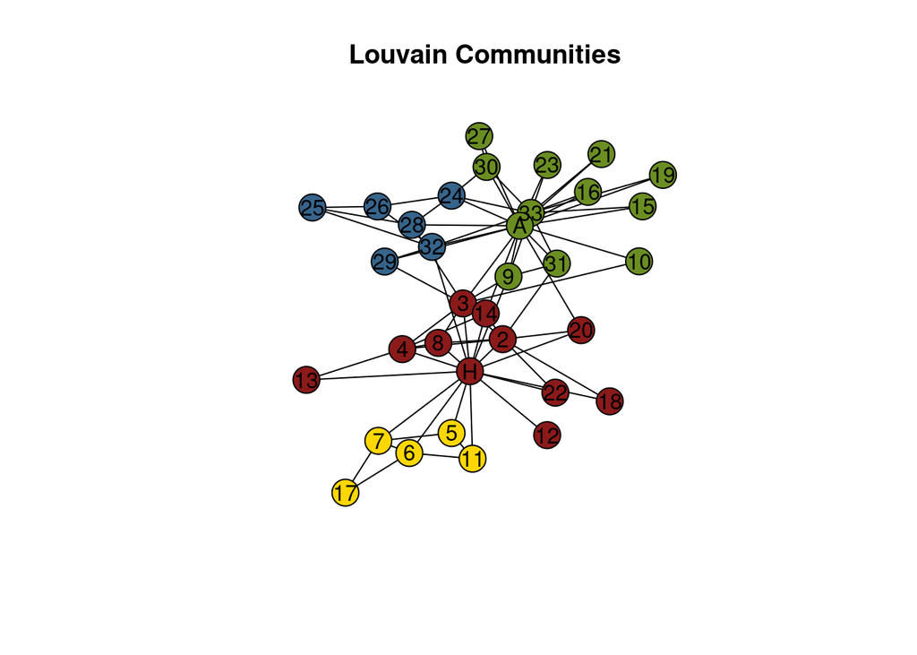

```r
V(karate)$community <- k_louvain$membership
colrs<-c("firebrick4", "gold", "olivedrab", "steelblue4")
plot(karate, vertex.color=colrs[V(karate)$community], vertex.label.color="black", vertex.label.family="sans", edge.color="black", main="Louvain Communities")
```

Στο σημείο αυτό μπορούμε να δούμε πώς μπορούμε να συσχετίσουμε διαφορετικές ομαδοποιήσεις για τους κόμβους του ίδιου δικτύου. Δείτε για παράδειγμα πώς συγκρίνονται οι 4 πυρήνες με τις 4 louvain κοινότητες για το δίκτυο Zachary. Αρχικά απλά απεικονίζοντας τις σχέσεις μεταξύ τους με την $table()$.

```r
table(V(karate)$community, kc)
```

```
##    kc
##     1 2 3 4
##   1 1 3 1 6
##   2 0 1 4 0
##   3 0 7 1 4
##   4 0 0 6 0
```

Και στη συνέχεια με την συνάρτηση $randIndex()$ που έχουμε ήδη συναντήσει στο Κεφάλαιο της Ομαδοποίησης (Κεφ 15).

```r
library(flexclust)
randIndex(table(V(karate)$community, kc))
```

```
##       ARI
## 0.2021176
```

### 17.8.3 Αποσπασματικότητα (Modularity) Δικτύων

Μια έννοια που σχετίζεται με τις κοινότητες δικτύων και είναι δύσκολο να αποδοθεί στα ελληνικά είναι το **modularity**, που θα μπορούσαμε να ερμηνεύσουμε ως “αποσπασματικότητα” (αν και θα προτιμήσουμε να κρατήσουμε τον αγγλικό όρο). To modularity είναι ένα μέτρο της δομής των δικτύων που μετρά την ένταση της διαίρεσης του δικτύου σε κοινότητες. Δίκτυα με υψηλό modularity έχουν πυκνές συνδέσεις μεταξύ των κόμβων εντός των κοινοτήτων, αλλά αραιές συνδέσεις μεταξύ κόμβων σε διαφορετικές κοινότητες, απ’όπου προκύπτει και η έννοια της “αποσπασματικότητας”. Διαφορετικά είδη δικτύων έχουν διαφορετικό βαθμό modularity με τα βιολογικά δίκτυα να έχουν συχνά μεγάλη αποσπασματικότητα.  
Μαθηματικά το modularity είναι *το κλάσμα των ακμών που εμπίπτουν στις δεδομένες κοινότητες μείον το αναμενόμενο κλάσμα εάν οι ακμές είχαν κατανεμηθεί τυχαία για ίδιο αριθμό κοινοτήτων και με ίδια πλήθη κόμβων ανά κοινότητα*. Η τιμή του μπορεί να είναι από -0.5 έως 1, όντας θετικό εάν ο αριθμός των άκρων εντός των ομάδων υπερβαίνει τον αριθμό που αναμένεται με βάση την τυχαιότητα. Μπορούμε να υπολογίσουμε το modularity με μια απλή εφαρμογή της ομώνυμης συνάρτησης με ορίσματα το ίδιο το δίκτυο και ένα διάνυσμα κοινοτήτων με την $membership()$.

```r
modularity(karate, membership(k_louvain))
```

```
## [1] 0.4197896
```

Βλέπουμε μια σχετικά υψηλή θετική τιμή, την οποία μπορούμε να συγκρίνουμε με ένα φυσικό, βιολογικό δίκτυο όπως αυτό των πρωτεϊνικών αλληλεπιδράσεων.

```r
yeast_louvain<-cluster_louvain(yeast)
modularity(yeast, membership(yeast_louvain))
```

```
## [1] 0.737076
```

Πράγματι βλέπουμε ότι το βιολογικό δίκτυο, αν και πολύ μεγαλύτερο και σαφώς πιο πολύπλοκο είναι και πολύ πιο modular.

Ως μια τελευταία ανάλυση μπορούμε να δούμε σε ποιο βαθμό οι κοινότητες του βιολογικού δικτύου αντανακλούν τις προϋπάρχουσες λειτουργικές τους κατηγορίες, εφαρμόζοντας μια ανάλυση με την $randIndex()$ πάνω στις δύο ομαδοποιήσεις.

```r
randIndex(table(V(yeast)$Class, membership(yeast_louvain)))
```

```
##       ARI
## 0.0733584
```

Βλέπουμε ότι η τιμή είναι μάλλον μικρή, οριακά πάνω από το 0, που υποδηλώνει ότι η ομαδοποίηση louvain δεν εντοπίζει ιδιότητες που να σχετίζονται με την κυτταρική λειτουργία, ή αντίστροφα ότι η κυτταρική λειτουργία δεν αντανακλάται στις σχέσεις του δικτύου αλληλεπιδράσεων.

## Συμπεράσματα

Στο κεφάλαιο αυτό προσπαθήσαμε να παρουσιάσουμε παράλληλα τις βασικές αρχές της θεωρίας για ένα πολύπλοκο και σύνθετο επιστημονικό πεδίο, αυτό της επιστήμης πολύπλοκων δικτύων και τις εφαρμογές της R για την διενέργεια αναλύσεων σε αντίστοιχα προβλήματα. Όπως και σε άλλα κεφάλαια, το βάρος έπεσε κυρίως στο δεύτερο. Το βιβλίο που κρατάτε στα χέρια σας είναι ένα εγχειρίδιο για την R και δεν φιλοδοξεί να καλύψει κάτι περισσότερο από τις θεωρητικές βάσεις των προβλημάτων που παρουσιάζονται στο πλαίσιο της ανάλυσης δεδομένων. Ακόμα κι έτσι θεωρούμε ότι ολοκληρώνοντάς το, ο αναγνώστης είναι σε θέση να πραγματοποιήσει ένα ικανοποιητικό αριθμό αναλύσεων σε δίκτυα και κυρίως να σχεδιάσει ακόμα πιο πολύπλοκες με βάση τα πιο σύνθετα ερευνητικά ερωτήματα που τυχόν θα έχει.

## Ασκήσεις

1. Στο δίκτυο UKfaculty, να εφαρμόσετε μια ανάλυση πυρηνικότητας και να απεικονίσετε το βαθμό πυρηνικότητας σε μια γραφική αναπαράσταση του δικτύου.
2. Στο δίκτυο yeast να υπολογίσετε τον βαθμό κάθε κόμβου και να αναπαραστήσετε σε μια γραφική παράσταση τον βαθμό του κόμβου, έναντι της κατάταξης των κόμβων από αυτόν με τον μικρότερο σε αυτόν με το μεγαλύτερο βαθμό. Στη συνέχεια να εξετάσετε τρόπους να προσαρμόσετε μια καμπύλη παλινδρόμησης σε αυτά τα σημεία.
3. Στο δίκτυο USairports να εντοπίσετε την κλίκα με το μεγαλύτερο μέγεθος και να αναφέρετε τα αεροδρόμια των ΗΠΑ που συνδέονται πλήρως.
4. Να γράψετε μια συνάρτηση που με δεδομένο ένα δίκτυο θα επιστρέφει το υποδίκτυο που θα αποτελεί την μεγαλύτερη κλίκα και θα την αναπαριστά γραφικά.
5. Στο δίκτυο yeast να πραγματοποιήσετε τις παρακάτω αναλύσεις: α. Να δημιουργήσετε το υποδίκτυο με τις ακμές υψηλής αξιοπιστίας και τους κόμβους που σχετίζονται με τον μεταβολισμό. β. Να ομαδοποιήσετε το δίκτυο με βάση τις κοινότητες louvain και να το αναπαραστήσετε γραφικά.
6. Στο ίδιο δίκτυο να εξαγάγετε τις louvain κοινότητες για τα υποδίκτυα με βάση όλες τις λειτουργικές κατηγορίες (A, B, C, D, E, F, G, M, O, P, R, T, U). Στη συνέχεια να υπολογίσετε το modularity για κάθε υποδίκτυο και να δημιουργήσετε έναν πίνακα με δύο μεταβλητές: τη λειτουρική κατηγορία και το modularity.
7. Σε τρια διαφορετικά δίκτυα από τη βιβλιοθήκη igraphdata: τα macaque, rfid και USairports. Να υπολογίσετε τη συσχέτιση μεταξύ βαθμού συσσωμάτωσης και διακεντρικότητας των κόμβων. (Σημ: Να χειριστείτε όλα τα δίκτυα ως μη-κατευθυνόμενα).
8. Στο δίκτυο enron, που περιέχει τα email μεταξύ των υπαλλήλων της Enron, να υπολογίσετε την ομοφιλία βαθμού κόμβων. Να τη συγκρίνετε με την αντίστοιχη τιμή που προκύπτει από το δίκτυο yeast. Τι διαφορές εντοπίζετε μεταξύ κοινωνικών και βιολογικών δικτύων;

## Εφαρμογή: Δίκτυα Ανεξάρτητα Κλίμακας

Κλείνοντας αυτό το κεφάλαιο θα πραγματοποιήσουμε μια ανάλυση δικτύων με σκοπό τη μελέτη μιας χαρακτηριστικής αναδυόμενης ιδιότητας, που χαρακτηρίζεται από την κατανομή του βαθμού των κόμβων και σχετίζεται με την οργάνωση του συστήματος. Συγκεκριμένα θα εξετάσουμε την ιδιότητα κάποιων δικτύων να είναι ανεξάρτητα-κλίμακος (scale-free). Τα ανεξάρτητα-κλίμακας δίκτυα, είναι δίκτυα που προκύπτουν από συγκεκριμένες δυναμικές διαδικασίες, ένα χαρακτηριστικό των οποίων είναι η δημιουργία “κεντρικών κόμβων” ή hubs, κόμβων δηλαδή που συγκεντρώνουν έναν μεγάλο αριθμό συνδέσεων και αποκτούν πολύ υψηλούς βαθμούς σε σχέση με άλλους κόμβους. Τα scale-free δίκτυα (στο εξής για συντομία SFN), διαφέρουν από τα δίκτυα, τα οποία προκύπτουν από μια τυχαία κατανομή των συνδέσεων στην κατανομή του βαθμού των κόμβων. Στα τυχαία δίκτυα (random networks, RN) οι βαθμοί των κόμβων δεν διαφέρουν ιδιαίτερα μεταξύ τους και ακολουθούν μια κανονική κατανομή. Στα SFN από την άλλη, μια δυναμική διαδικασία συσσωμάτωσης (aggregation) κάνει τους κόμβους με υψηλό βαθμό να προσελκύουν όλο και περισσότερες συνδέσεις (ακμές), αυξάνοντας έτσι περαιτέρω τον βαθμό τους και εκτρέποντας την κατανομή του βαθμού κόμβων σε όλο και μεγαλύτερες κλίμακες μεγέθους. Είναι αυτή η ιδιότητα που δίνει στα δίκτυα το όνομά τους (“ανεξάρτητα κλίμακας”), καθώς σε πολύ διαφορετικές κλίμακες μεγέθους τα ποιοτικά χαρακτηριστικά τους παραμένουν αναλοίωτα. Πάντα υπάρχουν κόμβοι με όλο και μεγαλύτερο βαθμό.

Ακριβώς λόγω αυτού του φαινομένου της προτιμησιακής σύνδεσης κόμβων υψηλού βαθμού, τα δίκτυα SFN εμφανίζονται σε πολλά διαφορετικά πεδία, από τις τηλεπικοινωνίες και την ανάλυση κειμένων, έως τη μετεωρολογία και τη βιολογία. Τα βιολογικά δίκτυα, όπως αυτό που εξετάσαμε σε αυτό το κεφάλαιο, αποτελούν ίσως τα πιο καλά μελετημένα SFN. Στην συνέχεια θα δούμε ένα διαφορετικό τέτοιο δίκτυο με σκοπό να μελετήσουμε: α. Τις γενικές του ιδιότητες β. Την στατιστική αντανάκλαση του φαινομένου ανεξαρτησίας κλίμακας γ. Τη σύγκριση του με τυχαία δίκτυα

Το σύνολο δεδομένων που θα μελετήσουμε αντιστοιχεί στο δίκτυο πρωτεϊνικών αλληλεπιδράσεων του παράγοντα νέκρωσης όγκων (Tumor Necrosis Factor, TNF), μιας πρωτεΐνης με κεντρικό ρόλο σε μια σειρά από κυτταρικές λειτουργίες. Τα δεδομένα έχουν αντληθεί από την βάση δεδομένων STRING (www.string-db.org) και μπορούν να βρεθούν στον παρακάτω σύνδεσμο: https://www.dropbox.com/s/h8tlpwfbajiym0b/TNFnetwork.txt.

Αρχικά, θα φορτώσουμε τα δεδομένα, θα εξετάσουμε τη δομή του αρχείου και θα δημιουργήσουμε ένα αντικείμενο δικτύου που θα μπορούμε να χειριστούμε με την $igraph$.

```r
tnfdata<-read.delim("TNFnetwork.txt", header=T, sep="\t")
str(tnfdata)
```

```
## 'data.frame':    545 obs. of  15 variables:
##  $ node1            : chr  "TNF" "NFATC2" "ICAM1" "UBC" ...
##  $ node2            : chr  "NFKB2" "TP53" "TNFRSF1A" "TRAF2" ...
##  $ node1_string_id  : int  1860103 1858353 1845628 1852861 1855067 1848511 1855661 1860103 1852280 1852861 ...
##  $ node2_string_id  : int  1855147 1846083 1842286 1843873 1852861 1845628 1842621 1848342 1846369 1850681 ...
##  $ node1_external_id: chr  "ENSP00000398698" "ENSP00000379330" "ENSP00000264832" "ENSP00000344818" ...
##  $ node2_external_id: chr  "ENSP00000358983" "ENSP00000269305" "ENSP00000162749" "ENSP00000247668" ...
##  $ neighborhood     : num  0 0 0 0 0 0 0 0 0 0 ...
##  $ fusion           : num  0 0 0 0 0 0 0 0 0 0 ...
##  $ cooccurence      : num  0 0 0 0 0 0 0 0 0 0 ...
##  $ homology         : num  0 0 0 0 0 0 0 0 0 0 ...
##  $ coexpression     : num  0 0 0 0 0 0 0 0 0.069 0 ...
##  $ experimental     : num  0 0 0 0.999 0.999 0.963 0 0 0.573 0.965 ...
##  $ knowledge        : num  0 0 0 0 0 0.9 0 0 0 0 ...
##  $ textmining       : num  0.973 0.865 0.528 0.07 0.102 0.87 0.415 0.76 0.193 0.139 ...
##  $ combined_score   : num  0.974 0.865 0.528 0.999 0.999 0.999 0.414 0.766 0.651 0.97 ...
```

Βλέπουμε ότι το σύνολο δεδομένων είναι ένα dataframe που περιέχει στις δύο πρώτες στήλες τα ζεύγη των κόμβων, ακολουθούμενες από στήλες με μια σειρά από σκορ αξιοπιστίας. Τα σκορ αυτά βασίζονται στις πηγές, από τις οποίες προκύπτει ο βαθμός αξιοπιστίας κάθε ακμής, ενώ η τελευταία στήλη περιέχει ένα συνδυαστικό σκόρ που συνοψίζει όλα τα επιμέρους.

Αρχικά θα δημιουργήσουμε ένα αντικείμενο δικτύου από τη λίστα των ακμών, όπως περιέχονται στις δύο πρώτες στήλες του dataframe.

```r
tnfnet<-graph_from_edgelist(as.matrix(tnfdata[,1:2]), directed=F)
tnfnet
```

```
## IGRAPH c3fbe1f UN-- 56 545 --
## + attr: name (v/c)
## + edges from c3fbe1f (vertex names):
##  [1] TNF     --NFKB2    NFATC2  --TP53     ICAM1   --TNFRSF1A UBC     --TRAF2
##  [5] UBC     --IKBKG    ICAM1   --ITGB2    MMP9    --NFKBIA   TNF     --FADD
##  [9] MYB     --SKP2     UBC     --GSK3B    NFKB2   --UBC      TNF     --ITGAL
## [13] TRAF6   --MED1     NFKB2   --ICAM1    ICAM1   --VCAM1    IKBKB   --RIPK1
## [17] CDKN2A  --SP1      TNF     --CREBBP   TNFRSF1A--CYLD     UBC     --BCL2
## [21] UBC     --FADD     KAT5    --EP300    TP53    --TIMP1    SMAD3   --NFKB1
## [25] EP300   --CHUK     TP53    --SMAD3    CDKN2A  --EP300    TNF     --IKBKG
## [29] ITGB2   --ITGAM    UBC     --FOXP3    ICAM1   --EP300    EP300   --SUPT3H
## + ... omitted several edges
```

Στο δίκτυο που δημιουργήσαμε, θα προσθέσουμε μια ιδιότητα στις ακμές που θα αντιστοιχεί στη μεταβλητή combined_score.

```r
E(tnfnet)$score<-tnfdata$combined_score
```

### A. Γενικές ιδιότητες δικτύου

Θα υπολογίσουμε αρχικά τις βασικές ιδιότητες του δικτύου, επικεντρώνοντας το ενδιαφέρον μας στον βαθμό των κόμβων, αφού αυτό είναι το κύριο χαρακτηριστικό με βάση το οποίο θα μελετήσουμε την ιδιότητα ανεξαρτησίας κλίμακας. Ας δούμε πρώτα κάποια γενικά τοπολογικά στοιχεία του δικτύου, τα οποία θα χρειαστούμε στο τελευταίο στάδιο, της σύγκρισης με ένα τυχαίο δίκτυο.

```r
print("network size")
```

```
## [1] "network size"
```

```r
length(V(tnfnet))
```

```
## [1] 56
```

```r
print("network density")
```

```
## [1] "network density"
```

```r
edge_density(tnfnet, loops = FALSE)
```

```
## [1] 0.3538961
```

```r
print("network diameter")
```

```
## [1] "network diameter"
```

```r
ds<-distances(tnfnet, V(tnfnet), V(tnfnet), mode = "all", algorithm = "dijkstra")
max(ds)
```

```
## [1] 3
```

Βλέπουμε ότι έχουμε να κάνουμε με ένα μάλλον πυκνό δίκτυο, 56 κόμβων, με σχετικά μεγάλη πυκνότητα, που αντανακλάται και στη μικρή διάμετρο.

H πυκνότητα του δικτύου φαίνεται και σε μια ανάλυση κλικών.

```r
clique_size_counts(tnfnet)
```

```
##  [1]    56   545  2464  6806 12924 17804 18168 13752  7610  2978   775   119
## [13]     8
```

Όπου βλέπουμε πολλές κλικες σε μεγέθη >5 και αρκετές ακόμα με μέγεθος >10.

### Β. Δίκτυα ανεξάρτητα κλίμακας. Κατανομή μεγέθους κόμβων

Προκειμένου να ελέγξουμε την ιδιότητα της ανεξαρτησίας κλίμακας θα πρέπει να δημιουργήσουμε την κατανομή του βαθμού κόμβων και να εξετάσουμε την μορφή της. Είναι εύκολο να υπολογίσουμε τους βαθμούς όλων των κόμβων με την συνάρτηση $degree()$.

```r
degree(tnfnet, mode="all")
```

```
##      TNF    NFKB2   NFATC2     TP53    ICAM1 TNFRSF1A      UBC    TRAF2
##       37       24       11       40       26       24       46       22
##    IKBKG    ITGB2     MMP9   NFKBIA     FADD      MYB     SKP2    GSK3B
##       25       11       21       26       19       17       13       22
##    ITGAL    TRAF6     MED1    VCAM1    IKBKB    RIPK1   CDKN2A      SP1
##        7       28       12       13       25       19       20       20
##   CREBBP     CYLD     BCL2     KAT5    EP300    TIMP1    SMAD3    NFKB1
##       29       13       37       13       32       14       21       42
##     CHUK    ITGAM    FOXP3   SUPT3H    BIRC2    SMAD2    PFDN5    BCL10
##       27       20       16        6       23       19        4       16
##    BIRC3      MYC   ZBTB17      MAX     CD83     RELB    SUMO1   MAP3K7
##       25       39       10       14        8       22       21       19
##    MED16      PLG    FBXW7    PIAS2    TRADD    CNTN2     IFNG   IFNGR1
##        7        8       10        9       16       10        9        3
```

Στη συνέχεια θα καταγράψουμε αυτές τις ποσότητες σε μια νέα μεταβλητή φροντίζοντας να κατατάξουμε τους κόμβους από αυτόν με τον ψηλότερο σε αυτόν με τον χαμηλότερο βαθμό.

```r
tnfdegrees <- sort(degree(tnfnet, mode="all"), decreasing = T)
```

Σαν τελευταίο στάδιο θα αναπαραστήσουμε γραφικά αυτήν την κατάταξη έναντι του βαθμού κόμβων. Αυτός είναι ο κλασσικός τρόπος δημιουργίας της κατανομής βαθμού κόμβων για τον έλεγχο της ιδιότητας που μας ενδιαφέρει. Στη συνέχεια δημιουργούμε ένα dataframe που θα περιέχει τους βαθμούς κόμβων σε συνδυασμό με την κατάταξη και ακολούθως το αναπαριστούμε γραφικά με την $ggplot()$.

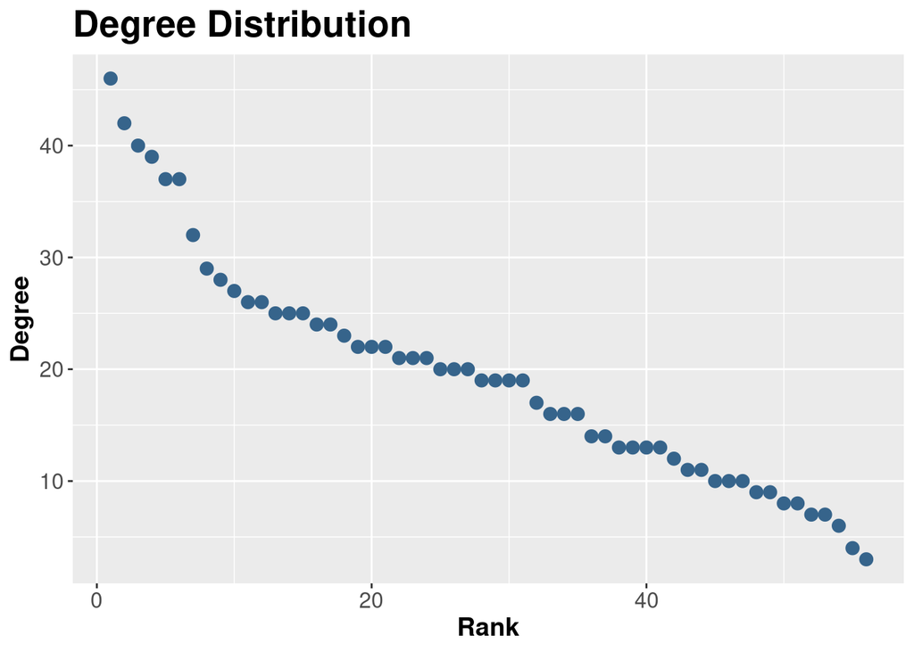

```r
df_real<-data.frame(Rank=seq(1:length(V(tnfnet))), Degree=tnfdegrees, Network="Real Network")
library(ggplot2)
ggplot(data=df_real) +
  geom_point(mapping = aes(x=Rank, y=Degree), col="steelblue4", size=3) +
  ggtitle("Degree Distribution") +
  theme(axis.text=element_text(size=12),axis.title=element_text(size=14,face="bold"), plot.title = element_text(size=20, face="bold"))
```

Η μορφή της κατανομής είναι ισχυρά δηλωτική ενός δικτύου ανεξάρτητου κλίμακας. Η μακριά “ουρά” της κατανομής και η αργή “απόσβεσή” της, δείχνει ότι υπάρχει επαρκώς μεγάλος αριθμός κόμβων με μεγάλο βαθμό (hubs). Συνηθίζουμε να αναπαριστούμε αυτές τις κατανομές σε διπλή λογαριθμική κλίμακα, δηλαδή λογαριθμώντας τα x, y, οπότε αυτή η μορφή αναδεικνύεται καλύτερα.

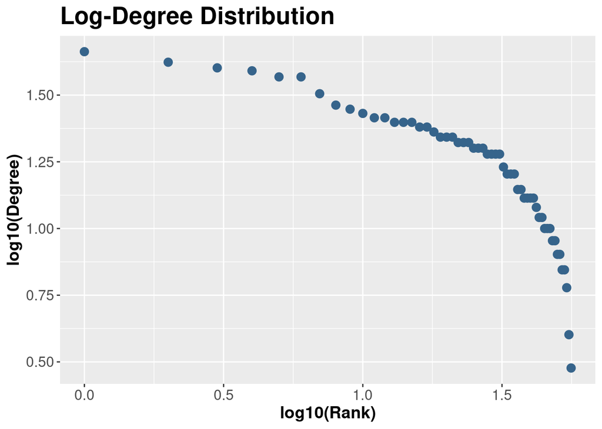

```r
ggplot(data=df_real) +
  geom_point(mapping = aes(x=log10(Rank), y=log10(Degree)), col="steelblue4", size=3) +
  ggtitle("Log-Degree Distribution") +
  theme(axis.text=element_text(size=12),axis.title=element_text(size=14,face="bold"), plot.title = element_text(size=20, face="bold"))
```

Βλέπουμε ότι η κατανομή “ανθίσταται” και παραμένει σε μεγάλα ύψη ακόμα και για μεγάλους βαθμούς κόμβων. Η μορφή της κατανομής υποδηλώνει σε μεγάλο βαθμό ότι το δίκτυο αλληλεπιδράσεων του TNF είναι ένα δίκτυο ανεξάρτητο κλίμακας. Ωστόσο αυτό θα φανεί πιο εύκολα αν το συγκρίνουμε με ένα τυχαίο δίκτυο.

### Γ. Σύγκριση με τυχαία δίκτυα

Τα τυχαία δίκτυα, όπως αναφέραμε και παραπάνω, δεν έχουν την τάση να δημιουργούν κεντρικούς κόμβους, καθώς σε αυτά οι ακμές κατανέμονται με τυχαίο τρόπο, χωρίς κάποια προτίμηση για κόμβους υψηλού βαθμού. Τυχαία δίκτυα επίσης συναντώνται στη φύση αν και, παραδόξως, μάλλον σπανιότερα από τα δίκτυα ανεξάρτητα κλίμακας.

Προκειμένου να έχουμε ένα αντιπροσωπευτικό δίκτυο σύγκρισης, ο ασφαλέστερος τρόπος είναι να τυχαιοποιήσουμε το ήδη υπάρχον. Με αυτόν τον τρόπο εξασφαλίζουμε ότι το μέγεθος του δικτύου σε ό,τι αφορά τους αριθμούς κόμβων και ακμών παραμένει ο ίδιος και το μόνο που θα αλλάξει είναι η εκπροσωπήσεις τους εντός των ζευγών κόμβων (ακμών), οι οποίες θα γίνουν τυχαία, δηλαδή ακριβώς με τον τρόπο που θέλουμε να προσομοιώσουμε. Η διαδικασία για κάτι τέτοιο είναι αρκετά απλή. Χρησιμοποιώντας αυτά που ξέρουμε για τις επαναληπτικές διαδικασίες (βλ. Κεφάλαιο 8), θα δημιουργήσουμε έναν βρόχο επανάληψης για έναν αριθμό φορών ίσο με τον αριθμό των ακμών του φυσικού δικτύου. Σε κάθε επανάληψη, θα δημιουργούμε ένα ζεύγος κόμβων, αντλώντας τυχαία από το σύνολο των κόμβων.  
Παρακάτω φαίνονται οι εντολές για αυτή τη διαδικασία.

```r
# random network initialization
node1<-vector(length=length(E(tnfnet)), mode="character")
node2<-vector(length=length(E(tnfnet)), mode="character")
# edge creation loop
for (i in 1:length(E(tnfnet))) {
  # random positions in the node vector
  x1<-sample(length(V(tnfnet)), 1)
  x2<-sample(length(V(tnfnet)), 1)
  # assignment to random edge list
  node1[i]<-names(V(tnfnet)[x1]) # names function added to extract only node-name
  node2[i]<-names(V(tnfnet)[x2])
}
# joining node1/node2 vectors into edge dataframe
randdata<-cbind(node1, node2)
# creating igraph network from edgelist
randnet<-graph_from_edgelist(as.matrix(randdata), directed=F)
```

Έχοντας δημιουργήσει το τυχαίο δίκτυο μπορούμε να δούμε κατευθείαν την κατανομή των κόμβων του όπως είδαμε για το φυσικό δίκτυο παραπάνω.

```r
randdegrees <- sort(degree(randnet, mode="all"), decreasing = T)
```

Και στη συνέχεια να το αναπαραστήσουμε μαζί με το φυσικό δίκτυο σαν κατανομή, αφού έχουμε επικαιροποιήσει το dataframe με τα νέα δεδομένα.

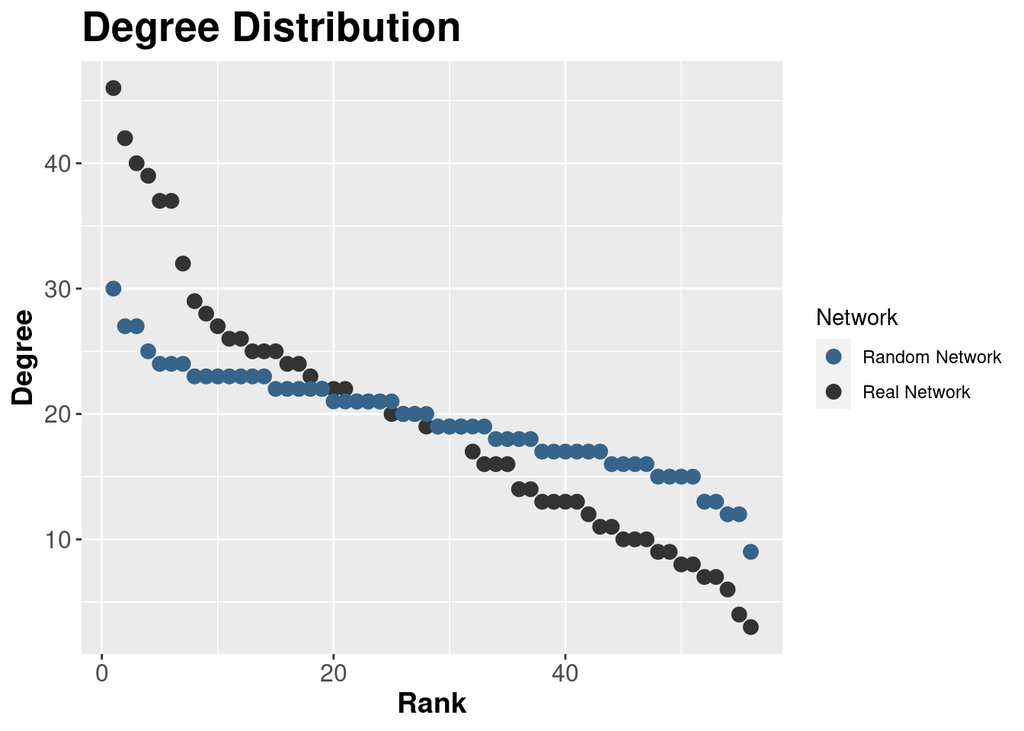

```r
df_random<-data.frame(Rank=seq(1:length(V(tnfnet))), Degree=randdegrees, Network="Random Network")
dftotal<-rbind(df_real, df_random)
ggplot(data=dftotal) +
  geom_point(mapping = aes(x=Rank, y=Degree, color=Network), size=3) +
  scale_color_manual(values=c("steelblue4", "grey20")) +
  ggtitle("Degree Distribution") +
  theme(axis.text=element_text(size=12),axis.title=element_text(size=14,face="bold"), plot.title = element_text(size=20, face="bold"))
```

Αυτό που βλέπουμε είναι ότι οι κατανομές διαφέρουν αρκετά, με βασικότερη διαφορά να είναι ότι το φυσικό δίκτυο έχει τιμές πάνω από το τυχαίο για τους κόμβους με μεγάλο βαθμό, ενώ το αντίθετο συμβαίνει για τους κόμβους μικρού βαθμού. Αυτή η ποιοτική διαφορά μπορεί να ποσοτικοποιηθεί και με αυστηρότερο τρόπο, ωστόσο μια τέτοια ανάλυση αφήνεται για πιο εξειδικευμένες αναλύσεις. Συνολικά, αυτό που προκύπτει είναι ότι το φυσικό δίκτυο τείνει να έχει περισσότερα hubs, δηλαδή κόμβους υψηλού βαθμού όπως γνωρίζουμε ότι συμβαίνει για τα δίκτυα ανεξάρτητα κλίμακας.

Μπορούμε να δούμε πώς αποτυπώνεται αυτή η διαφορά και γραφικά αναπαριστώντας τα δίκτυα με κοινότητες louvain.

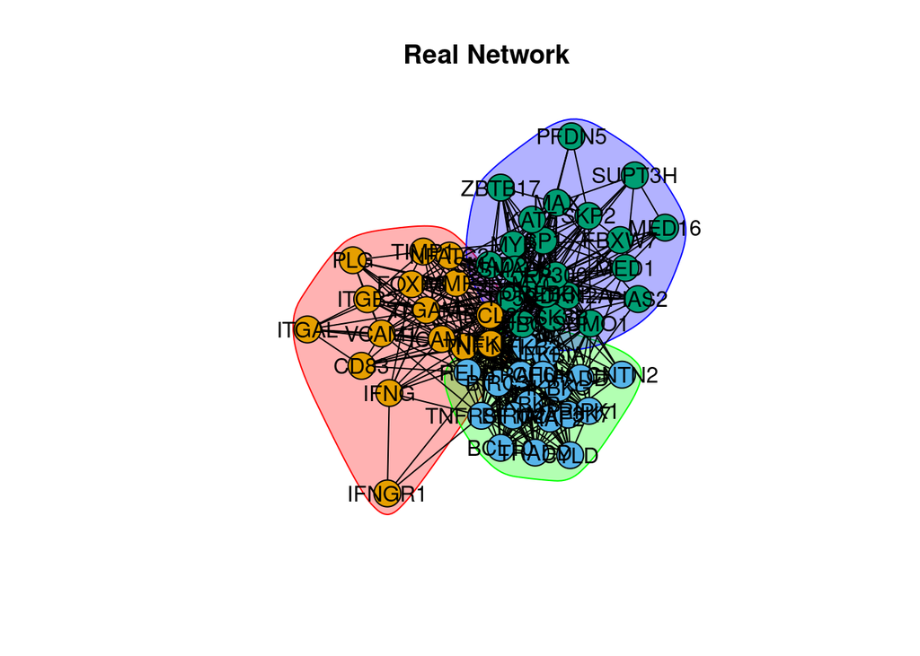

```r
k_louvain<-cluster_louvain(tnfnet)
plot(k_louvain, tnfnet, vertex.size=V(tnfnet)$degree, vertex.label.color="black", vertex.label.family="sans", edge.color="black", main="Real Network")
```

Ενώ η ίδια αναπαράσταση για το τυχαίο δίκτυο είναι η παρακάτω

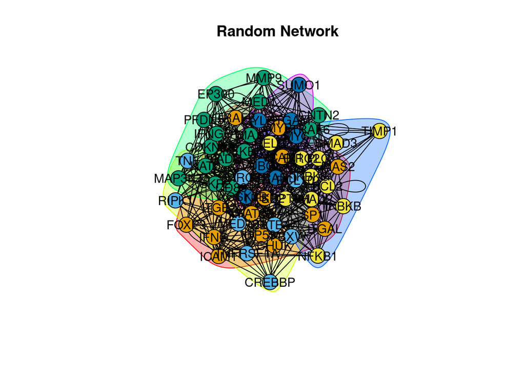

```r
k_louvain_r<-cluster_louvain(randnet)
plot(k_louvain_r, randnet, vertex.size=V(randnet)$degree, vertex.label.color="black", vertex.label.family="sans", edge.color="black", main="Random Network")
```

```r
print("Real Network Modularity")
```

```
## [1] "Real Network Modularity"
```

```r
modularity(tnfnet, membership(k_louvain))
```

```
## [1] 0.2504722
```

```r
print("Random Network Modularity")
```

```
## [1] "Random Network Modularity"
```

```r
modularity(randnet, membership(k_louvain_r))
```

```
## [1] 0.2151351
```

Συμπερασματικά, μπορούμε να πούμε ότι το φυσικό δίκτυο πρωτεϊνικών αλληλεπιδράσεων του TNF έχει υψηλή πυκνότητα, εμφανίζει στοιχεία ενός ανεξάρτητου κλίμακας δικτύου, με μεγάλο συγκριτικά αριθμό κεντρικών κόμβων και σχετικά υψηλό βαθμό αποσπασματικότητας.